# STAT 434 Final Project

Emma Barton & Ryan Vosbigian

6/10/2020

# Introduction

Understanding species and identifying potential for endangerment and extinction is essential to protecting species and biodiversity. However, it is difficult to monitor and track every species and their individual risks. The International Union for Conservation of Nature (2020) maintains a list of the status of all known species, but there are many that are still unknown, due to lack of research focused on those species. The status outlined by the IUCN Redlist are in order of lowest to highest risk of endangerement and extinction: least concern, near threatened, vulnerable, endangered, highly endangered, extinct in the wild, extinct. The IUCN lists another option of unknown.

While many individual species have not been studied enough to determine status, there are species databases that have compiled information on all bird and mammal species. Elton Traits, which was created by Wilman and colleagues (2014), has compiled diet and foraging variables for all currently existing birds and mammals and used interpolation based on similar traits and phylogentic relationships to fill in for missing traits.

These foraging and diet characteristics could help predict status, because species that share similar food sources or foraging strageties could be influenced similarly by human activities and other pressures. Alternatively, decreased competition between similar species if one becomes endangered could lead to more opportunities and higher fitness for similar species. Additionally, traits that could be affected by pressures in one area, such as a city, could be different than traits that are threatened by pressures in forests such as from logging.

We combined the IUCN’s Redlist status of birds and mammals with the Elton Traits database, and used traits of birds and mammals to predict status. We used classification models, to predict whether species is least concern, near threatened, vulnerable, or endangered, where we lumped endangered, highly endangered, extinct in wild, and extinct into one category. These were combined, because between when the Elton Traits were published in 2014 and 2020 when the IUCN Redlist were updated, some species went extinct, so there were low numbers in each of those categories and lumping helped make the models more generalizable.

After determining the best model that predicts status, we used the model to predicted the IUCN Redlist Status for the species where the status is unknown.

# Data Cleaning

```r
library(tidyverse)
library(Hmisc)
library(class)
library(tree)
library(randomForest)
library(MASS)
library(e1071)
library(nnet)
library(gbm)
## Local Pathways - copy/paste your local pathway to the github repository

# Emma
pathway = "/Users/emmabarton/Desktop/spring_2020/STAT434/project/"

# Ryan
#pathway = "~/GitHub/"
```

## Loading Datasets

```r
redlist_df = read.csv(paste0(pathway, "STAT-434---not-the-dodo-/simple_summary_IUCN_birds_mammals.csv"))

elton_mammal_df = read.csv(paste0(pathway, "STAT-434---not-the-dodo-/EltonTraits/MamFuncDat.txt"),sep = "\t")

elton_bird_df = read.csv(paste0(pathway, "STAT-434---not-the-dodo-/EltonTraits/BirdFuncDat.txt"),sep = "\t")
```

```r
redlist_df$scientificName = as.character(redlist_df$scientificName)
elton_mammal_df$scientificName = as.character(elton_mammal_df$Scientific)
elton_bird_df$scientificName = as.character(elton_bird_df$Scientific)
```

```r
# Filter mammals and birds from redlist species
redlist_mammals_df = redlist_df[redlist_df$className=="MAMMALIA",]
redlist_birds_df = redlist_df[redlist_df$className=="AVES",]

# Join Elton traits and redlist species for mammals
mammal_df = left_join(x = elton_mammal_df, y = redlist_mammals_df,
                      by="scientificName")

# Join Elton traits and redlist species for birds
bird_df = left_join(x = elton_bird_df, y = redlist_birds_df,
                    by="scientificName")

# Write data
write.csv(mammal_df, "uncleaned_mammal_df.csv")
write.csv(bird_df, "uncleaned_bird_df.csv")
```

```r
mammal_df = read.csv("uncleaned_mammal_df.csv")
bird_df = read.csv("uncleaned_bird_df.csv")
```

## Data Cleaning

```r
dim(mammal_df)
dim(bird_df)
```

```r
table(is.na(mammal_df$Diet.Vect))
nrow(mammal_df)
nrow(elton_mammal_df)
nrow(redlist_mammals_df)

# Check redlist mammals that do not have Elton traits
redlist_mammals_df %>%
  filter(!(scientificName %in% elton_mammal_df$scientificName)) %>%
  nrow()

# Check redlist birds that do not have Elton traits
redlist_birds_df %>%
  filter(!(scientificName %in% elton_bird_df$scientificName)) %>%
  nrow()
```

```r
# Removed unnecessary or mostly empty columns
mammal_df = mammal_df %>%
  select(-X, -MSW3_ID, -infraType, -infraName, -infraAuthority,
         -redlistCriteria, -criteriaVersion)

bird_df = bird_df %>%
  select(-X, -infraType, -infraName, -infraAuthority,
         -redlistCriteria, -criteriaVersion)
```

```r
mammal_df %>%
  filter(is.na(redlistCategory)) %>%
  nrow()

bird_df %>%
  filter(is.na(redlistCategory)) %>%
  nrow()
```

```r
# Create prediction/test datasets
mammal_pred_df = mammal_df %>%
  filter(is.na(redlistCategory))

bird_pred_df = bird_df %>%
  filter(is.na(redlistCategory))

# Filter out rows with missing redlist category to make training dataset
mammal_df = mammal_df %>%
  filter(!is.na(redlistCategory))

bird_df = bird_df %>%
  filter(!is.na(redlistCategory))
```

```r
mammal_df = mammal_df %>%
  mutate(
    populationTrend = case_when(
      populationTrend == "" ~ "Unknown",
      TRUE ~ as.character(populationTrend)
    )
  )
```

```r
write.csv(mammal_df, "cleaned_mammal_df.csv")
write.csv(bird_df, "cleaned_bird_df.csv")

write.csv(mammal_pred_df, "mammal_pred_df.csv")
write.csv(bird_pred_df, "bird_pred_df.csv")
```

Not having much luck matching these 500 mammal taxons. maybe just drop them??

```r
# matching MAMMAL species that didnt have a perfect match between the IUCN and EltonTraits databases
mammal_pred_df = read.csv("mammal_pred_df.csv")

syn_df = read.csv("asm-species-2020-05-27_containssynonymsfromeltontraits.csv")

#removing the empty columns from the missing IUCN join
mammal_pred_df = mammal_pred_df[,1:27]

#reformatting the deprecated.scientific name column from: {"herpestes javanica":":$2009"}

#chopping off the first two characters

syn_df$Deprecated.Scientific = gsub('^."([^"]*[^"]*)".*$', "\\1",syn_df$Deprecated.Scientific)

#capitalizing
syn_df$Deprecated.Scientific = capitalize(syn_df$Deprecated.Scientific)

mammal_pred_df %>%
  filter(!(scientificName %in% syn_df$Deprecated.Scientific)) %>%
  unique()

mammal_pred_df$scientificName = as.character(mammal_pred_df$scientificName)
syn_df$Deprecated.Scientific = as.character(syn_df$Deprecated.Scientific)
syn_df$Canonical.Sciname = as.character(syn_df$Canonical.Sciname)

for (i in 1:nrow(mammal_pred_df)){
  sci_index = match(mammal_pred_df$scientificName[i],syn_df$Deprecated.Scientific)
  if (is.na(sci_index)==FALSE) {
    mammal_pred_df$scientificName[i] = syn_df$Canonical.Sciname[sci_index]
  }else {
    mammal_pred_df$scientificName[i] = NA
  }
}
```

TaxonomicChanges_BirdLife_Avibase.csv was scrapped from avibase.bs-eoc.org https://avibase.bsc-eoc.org/compare.jsp?source1=birdlife&version1=BIRDLIFE03&source2=birdlife&version2=BIRDLIFE12&continent=&reg_type=9

It is a table with that matches the Birdlife checklist version 3 (EltonTraits uses) with the HBW Birdlife Taxonomic Checklist v4 (which IUCN uses). Using this table to change names to the new taxonomic system to change the taxonomic system used in EltonTraits to the more updated v4.

http://datazone.birdlife.org/species/taxonomy ^birdlife taxonomy

```r
# matching BIRDS that didnt have a perfect match between the IUCN and EltonTraits databases
mammal_pred_df = read.csv("mammal_pred_df.csv")

bird_pred_df = read.csv("bird_pred_df.csv")

avibase_df = read.csv("TaxonomicChanges_Birdlife_Avibase.csv")
avibase_df = avibase_df[,2:ncol(avibase_df)] #chopping off the
avibase_ioc_df = read.csv("TaxonomicChanges_IOC27_HBWBirdlife4.csv")
avibase_ioc_df$Scientific.name = avibase_ioc_df$'ï..Scientific.name'

#matching taxonomy from Birdlife v3 to HBW v4, filtering out ones that don't match (the ones using taxonomy IOC 2.7 don't match)
bird_pred_df %>%
  filter((!scientificName %in% avibase_df$Scientific.name)) %>%
  unique()

#looking at taxons that don't match within IOC2.7 or birdlife v3
bird_pred_df %>%
  filter((!scientificName %in% avibase_df$Scientific.name)) %>%
  filter((!scientificName %in% avibase_ioc_df$Scientific.name)) %>%
  unique()

#changing to character to avoid errors
bird_pred_df$scientificName = as.character(bird_pred_df$scientificName)
avibase_df$Scientific.name = as.character(avibase_df$Scientific.name)
avibase_df$Scientific.name2 = as.character(avibase_df$Scientific.name2)
avibase_ioc_df$Scientific.name = as.character(avibase_ioc_df$Scientific.name)
avibase_ioc_df$Scientific.name2 = as.character(avibase_ioc_df$Scientific.name2)

#loop through and update name to correct taxon
for(i in 1:nrow(bird_pred_df)) {
  sci_index = match(bird_pred_df$scientificName[i],avibase_df$Scientific.name,nomatch=0)
  if(sci_index==0){ # then is in IOC2.7 database
    sci_index = match(bird_pred_df$scientificName[i],avibase_ioc_df$Scientific.name,nomatch=0)
    if(sci_index!=0){ #if it matches, then we assign it to the correct taxonomy
      bird_pred_df$scientificName[i] = avibase_ioc_df$Scientific.name2[sci_index]
    }else{
      bird_pred_df$scientificName[i] = NA
    }

  }else{ # then is in the birdlife 3 database and assign it to the correct taxonomy
    bird_pred_df$scientificName[i] = avibase_df$Scientific.name2[sci_index]
  }
}

#saving those with missing taxonomy to a datafile
bird_pred_df %>%
  filter(scientificName == "") %>%
  write.csv("missingtaxonomy_birds.csv")

#removing those taxons with missing taxonomy
bird_pred_df2 = bird_pred_df %>%
  filter(scientificName != "")

#chopping off some columns
bird_pred_df2 = bird_pred_df2[,1:42]

redlist_birds_df$scientificName = as.character(redlist_birds_df$scientificName)

new_bird_df = left_join(x = bird_pred_df2, y = redlist_birds_df,
                    by="scientificName")

clean_bird_df = read.csv("cleaned_bird_df.csv")

colnames(clean_bird_df)
colnames(new_bird_df)

new_bird_df = new_bird_df %>%
  dplyr::select(-infraType, -infraName, -infraAuthority,
         -redlistCriteria, -criteriaVersion)

new_clean_bird_df = rbind(clean_bird_df,new_bird_df)

write.csv(new_clean_bird_df,"cleaned_bird_df_updated_5_29.csv")
```

# Data Exploration

## Set Up

```r
mammal_df = read.csv("cleaned_mammal_df.csv")
bird_df = read.csv("cleaned_bird_df_updated_5_29.csv")
```

## Data Exploration

Elton traits: diet, foraging strata, foraging time, and body size.

## Mammals

```r
names(mammal_df)
```

```
##  [1] "X"                    "Scientific"           "MSWFamilyLatin"
##  [4] "Diet.Inv"             "Diet.Vend"            "Diet.Vect"
##  [7] "Diet.Vfish"           "Diet.Vunk"            "Diet.Scav"
## [10] "Diet.Fruit"           "Diet.Nect"            "Diet.Seed"
## [13] "Diet.PlantO"          "Diet.Source"          "Diet.Certainty"
## [16] "ForStrat.Value"       "ForStrat.Certainty"   "ForStrat.Comment"
## [19] "Activity.Nocturnal"   "Activity.Crepuscular" "Activity.Diurnal"
## [22] "Activity.Source"      "Activity.Certainty"   "BodyMass.Value"
## [25] "BodyMass.Source"      "BodyMass.SpecLevel"   "scientificName"
## [28] "assessmentId"         "internalTaxonId"      "kingdomName"
## [31] "phylumName"           "orderName"            "className"
## [34] "familyName"           "genusName"            "speciesName"
## [37] "authority"            "redlistCategory"      "populationTrend"
## [40] "scopes"
```

Diet variables are the estimated percent use of Inv: invertebrates Vend: mammals and birds, Vect: reptiles, snakes, amphibians, salamanders, Vfish: fish, Vunk: general vertebrates or unknown, Scav: scavenge, garbage, offal, carcasses, trawlers, carrion, Fruit: fruit and drupes, Nect: nector, pollen, plant exudates, gums, Seed: seed, maize, nuts, spores, wheat, grains, Plant: other plant material. All diet categories should add to 100%.

Diet source is a reference ID and diet certainty is the estimated reliability of the diet sources (see metadata for rankings).

ForStrat.Value: One of five foraging stratum categories (marine, ground, scansorial, arboreal, aerial).

Activity variables are binary 0:no, 1:yes. Nocturnal: night, Crepuscular: twilight, Diurnal: day.

Bodymass.Value: average adult body mass (g)

Redlist Category: Critically Endangered, Data Deficient, Endangered, Extinct, Extinct in the Wild, Least Concern, Near Threatened, Vulnerable

### Single Variable Distributions

```r
# Response: Redlist Category
table(mammal_df$redlistCategory)
```

```
##
## Critically Endangered        Data Deficient            Endangered
##                   159                   574                   413
##               Extinct   Extinct in the Wild         Least Concern
##                    52                     2                  2911
##       Near Threatened            Vulnerable
##                   299                   456
```

```r
# Body Mass distribution
mammal_df %>%
  mutate(
    bodymass_bin = case_when(
      BodyMass.Value >= 100000 ~ ">=100,000",
      BodyMass.Value < 100000 & BodyMass.Value >= 10000 ~ "10,000 - 100,000",
      BodyMass.Value < 10000 & BodyMass.Value >= 1000 ~ "10,000 - 1,000",
      BodyMass.Value < 1000 & BodyMass.Value >= 100 ~ "1,000 - 100",
      BodyMass.Value < 100 ~ "<100"
     )
  ) %>%
  group_by(bodymass_bin) %>%
  dplyr::summarize(n = n())
```

```
## # A tibble: 5 x 2
##   bodymass_bin         n
##   <chr>            <int>
## 1 <100              2734
## 2 >=100,000          160
## 3 1,000 - 100       1069
## 4 10,000 - 1,000     629
## 5 10,000 - 100,000   274
```

The majority of species in our dataset are of least concern, followed by data deficient and vulnurable. However, combining critically endangered, endangered, extinct, and extinct in the wild results in 626 species.

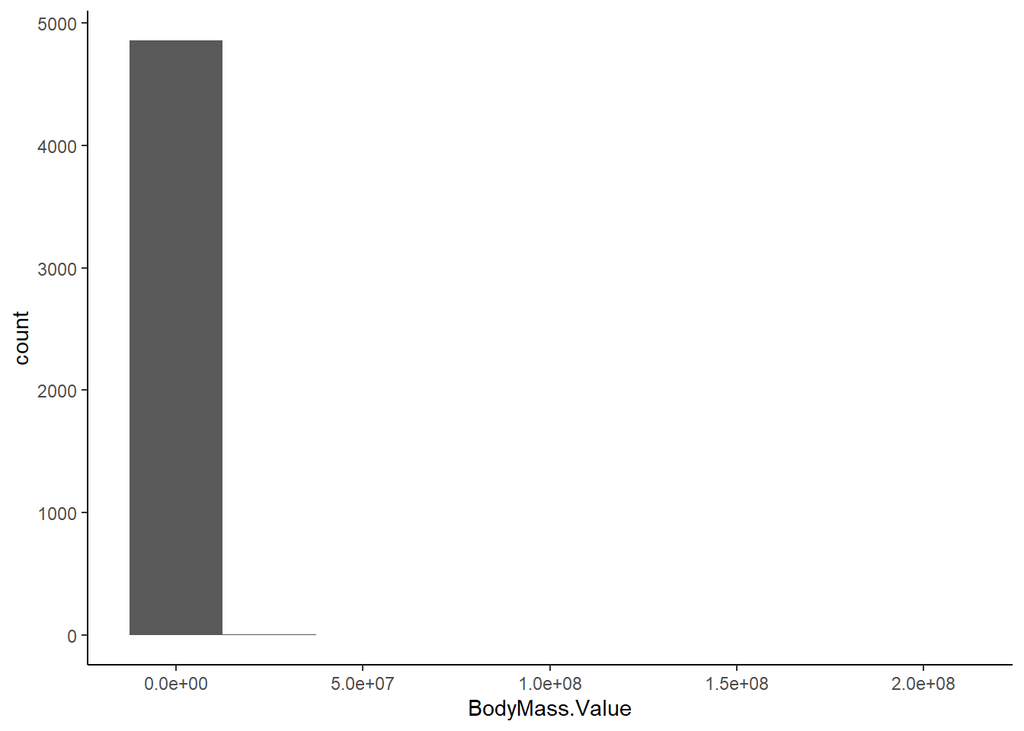

```r
# Body Mass Histogram
ggplot(mammal_df, aes(BodyMass.Value)) +
  geom_histogram(binwidth = 25000000) +
  theme_classic()
```

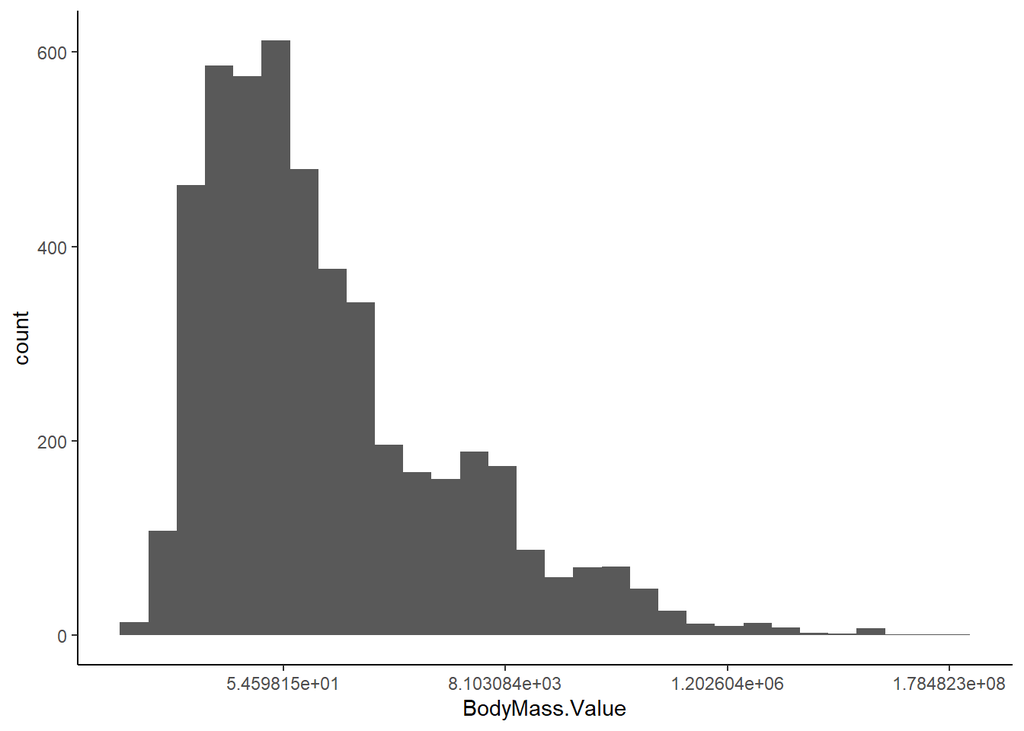

```r
# Log Transformed Body Mass Histogram
ggplot(mammal_df, aes(BodyMass.Value)) +
  geom_histogram() +
  scale_x_continuous(trans = "log") +
  theme_classic()
```

Because of the large disparity between large mammals with a much greater body mass than 100,000 and the majority of mammals, the distribution of bodymass is very skewed right.

### Pairwise Relationships

```r
# Redlist Category vs Population Trend
table(mammal_df$redlistCategory, mammal_df$populationTrend)
```

```
##
##                         Decreasing Increasing Stable Unknown
##   Critically Endangered        132          1      5      21
##   Data Deficient                37          0      5     532
##   Endangered                   350          7      5      51
##   Extinct                        0          0      0      52
##   Extinct in the Wild            0          0      0       2
##   Least Concern                413         58   1165    1275
##   Near Threatened              225          5     13      56
##   Vulnerable                   363          8     28      57
```

```r
# Redlist Category vs Foraging Stratum
prop.table(table(mammal_df$redlistCategory,mammal_df$ForStrat.Value),2)*100 #makes a nice looking table with % by column
```

```
##
##                                   A          Ar           G           M
##   Critically Endangered  1.44717800  6.38977636  2.77577505  2.50000000
##   Data Deficient        18.23444284  9.37167199 10.99495314 20.00000000
##   Endangered             4.05209841 13.52502662  7.85868782 13.33333333
##   Extinct                0.00000000  0.53248136  1.62220620  0.83333333
##   Extinct in the Wild    0.00000000  0.00000000  0.07209805  0.00000000
##   Least Concern         62.95224313 48.77529286 63.01369863 49.16666667
##   Near Threatened        6.22286541  6.92225772  5.83994232  5.00000000
##   Vulnerable             7.09117221 14.48349308  7.82263879  9.16666667
##
##                                   S
##   Critically Endangered  2.63157895
##   Data Deficient         9.06432749
##   Endangered             7.01754386
##   Extinct                0.29239766
##   Extinct in the Wild    0.00000000
##   Least Concern         61.69590643
##   Near Threatened        6.72514620
##   Vulnerable            12.57309942
```

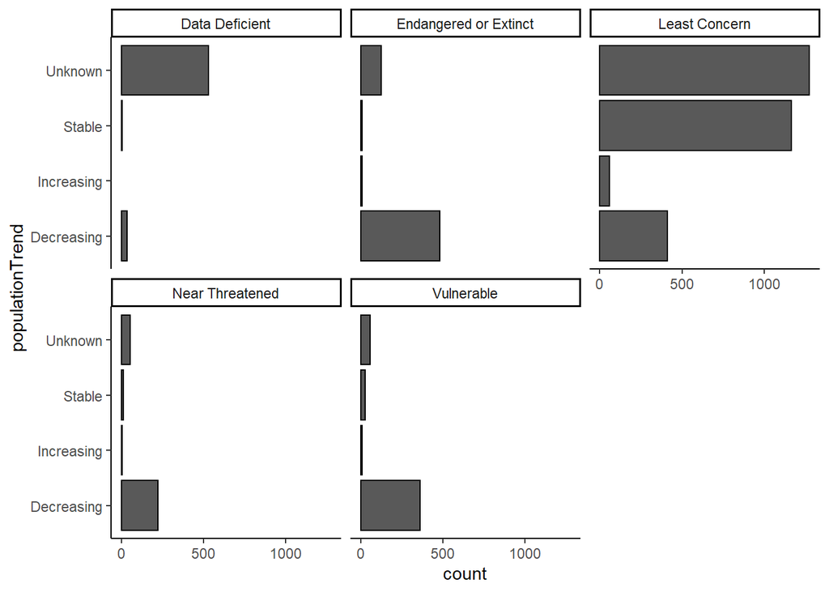

```r
# 1
# Population Trend and Redlist Category Bar Plot
mammal_df %>%
  mutate(
    redlistCat2 = case_when(
      redlistCategory == "Critically Endangered" ~ "Endangered or Extinct",
      redlistCategory == "Endangered" ~ "Endangered or Extinct",
      redlistCategory == "Extinct" ~ "Endangered or Extinct",
      redlistCategory == "Extinct in the Wild" ~ "Endangered or Extinct",
      TRUE ~ as.character(redlistCategory)
    )
  ) %>%
  ggplot(aes(populationTrend)) +
    geom_bar(col = "black") +
    facet_wrap(~redlistCat2) +
    coord_flip() +
    theme_classic()
```

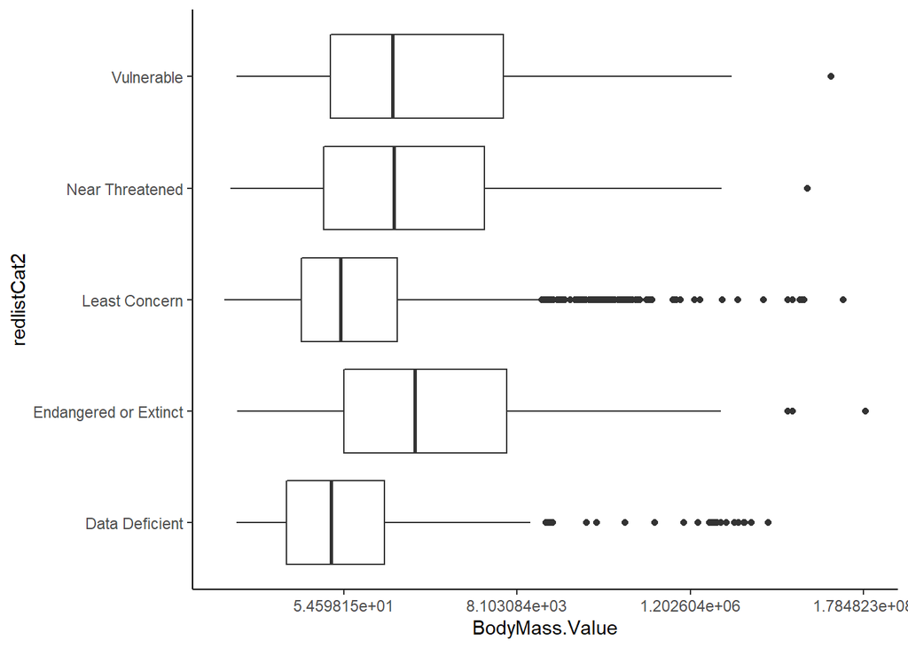

```r
# 2
# Redlist Category vs Body Mass Value Box Plot
mammal_df %>%
  mutate(
    redlistCat2 = case_when(
      redlistCategory == "Critically Endangered" ~ "Endangered or Extinct",
      redlistCategory == "Endangered" ~ "Endangered or Extinct",
      redlistCategory == "Extinct" ~ "Endangered or Extinct",
      redlistCategory == "Extinct in the Wild" ~ "Endangered or Extinct",
      TRUE ~ as.character(redlistCategory)
    )
  ) %>%
  ggplot(aes(redlistCat2, BodyMass.Value)) +
    geom_boxplot() +
    coord_flip() +
    scale_y_continuous(trans = "log") +
    theme_classic()
```

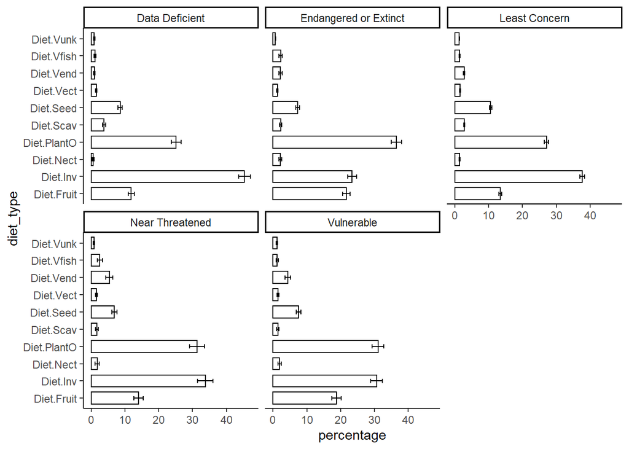

```r
# 3
# Average Diet Percent Use vs Redlist Category Barplots
mammal_df %>%
  mutate(
    redlistCat2 = case_when(
      redlistCategory == "Critically Endangered" ~ "Endangered or Extinct",
      redlistCategory == "Endangered" ~ "Endangered or Extinct",
      redlistCategory == "Extinct" ~ "Endangered or Extinct",
      redlistCategory == "Extinct in the Wild" ~ "Endangered or Extinct",
      TRUE ~ as.character(redlistCategory)
    )
  ) %>%
  gather(key = "diet_type", value = "percentage", Diet.Inv, Diet.Vend,
         Diet.Vect, Diet.Vfish, Diet.Vunk, Diet.Scav, Diet.Fruit, Diet.Nect,
         Diet.Seed, Diet.PlantO) %>%
  ggplot(aes(diet_type, percentage)) +
    stat_summary(geom = "bar", fun = mean, position = position_dodge(),
                 colour = "black", fill = "white",
                 width = 0.7) +
    stat_summary(geom = "errorbar", fun.data = mean_se,
                 position = position_dodge(0.7),
                 width = 0.25) +
    facet_wrap(~redlistCat2) +
    coord_flip() +
    theme_classic()
```

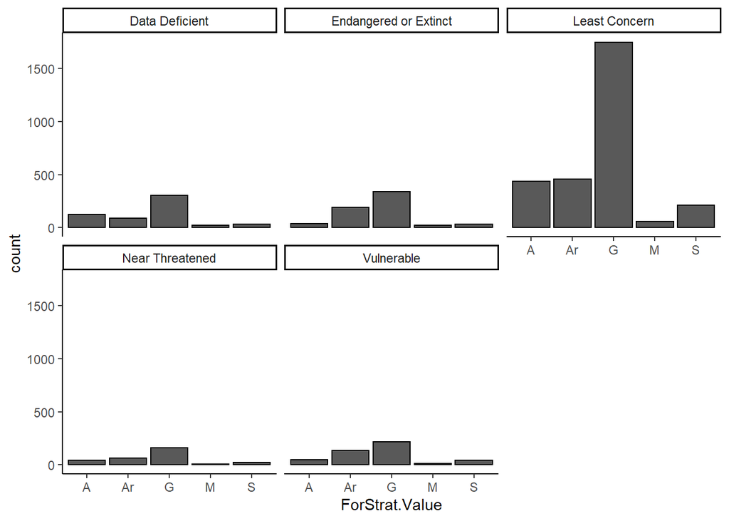

```r
# 4
# Foraging Stratum and Redlist Category Bar Plot
mammal_df %>%
  mutate(
    redlistCat2 = case_when(
      redlistCategory == "Critically Endangered" ~ "Endangered or Extinct",
      redlistCategory == "Endangered" ~ "Endangered or Extinct",
      redlistCategory == "Extinct" ~ "Endangered or Extinct",
      redlistCategory == "Extinct in the Wild" ~ "Endangered or Extinct",
      TRUE ~ as.character(redlistCategory)
    )
  ) %>%
  ggplot(aes(ForStrat.Value)) +
    geom_bar(col = "black") +
    facet_wrap(~redlistCat2) +
    theme_classic()
```

1) The majority of endangered or extinct mammals (critically endangered, endangered, extinct, and extinct in the wild grouped into one category) have a decreasing population trend. The majority of vulnerable and near threatened mammals also have a decreasing population trend. The majority of least concern mammals have either a stable population trend or an unknown population trend.

It is very likely that the redlist category of a mammal is designated based on population trend knowledge. Many of the mammals in the least concern category may actually be more threatened than believed becasue their population trend is unknown.

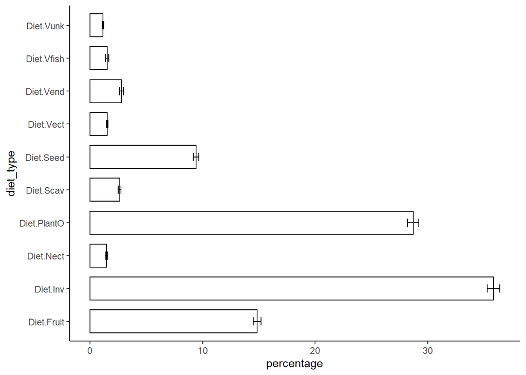

```r
# 5
# Average Percent Use of Each Diet Type
mammal_df %>%
  gather(key = "diet_type", value = "percentage", Diet.Inv, Diet.Vend,
         Diet.Vect, Diet.Vfish, Diet.Vunk, Diet.Scav, Diet.Fruit, Diet.Nect,
         Diet.Seed, Diet.PlantO) %>%
  ggplot(aes(diet_type, percentage)) +
    stat_summary(geom = "bar", fun = mean, position = position_dodge(),
                 colour = "black", fill = "white",
                 width = 0.7) +
    stat_summary(geom = "errorbar", fun.data = mean_se,
                 position = position_dodge(0.7),
                 width = 0.25) +
    coord_flip() +
    theme_classic()
```

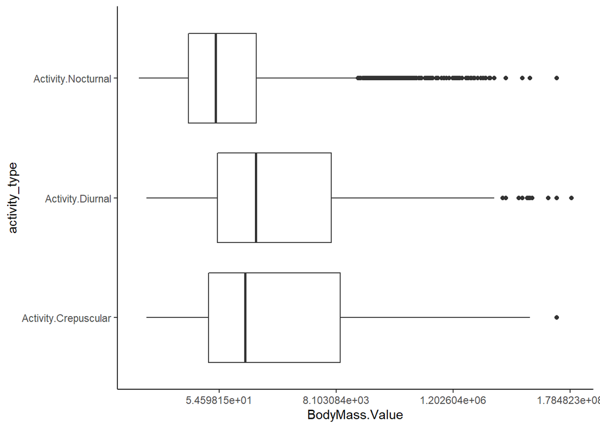

```r
# 6
# Activity vs Body Mass Boxplot
mammal_df %>%
  gather(key = "activity_type", value = "value", Activity.Nocturnal,
         Activity.Crepuscular, Activity.Diurnal) %>%
  filter(value == 1) %>%
  ggplot(aes(activity_type, BodyMass.Value)) +
    geom_boxplot() +
    scale_y_continuous(trans = "log") +
    coord_flip() +
    theme_classic()
```

5) Invertebrates were the diet component with the highest average percent use, followed by other plant parts and fruit.

6. Average body mass value for each activity type. Diurnal and Crepuscular have slightly larger median bodymass values.

## Birds

```r
names(bird_df)
```

```
##  [1] "X.1"                    "X"                      "SpecID"
##  [4] "PassNonPass"            "IOCOrder"               "BLFamilyLatin"
##  [7] "BLFamilyEnglish"        "BLFamSequID"            "Taxo"
## [10] "Scientific"             "English"                "Diet.Inv"
## [13] "Diet.Vend"              "Diet.Vect"              "Diet.Vfish"
## [16] "Diet.Vunk"              "Diet.Scav"              "Diet.Fruit"
## [19] "Diet.Nect"              "Diet.Seed"              "Diet.PlantO"
## [22] "Diet.5Cat"              "Diet.Source"            "Diet.Certainty"
## [25] "Diet.EnteredBy"         "ForStrat.watbelowsurf"  "ForStrat.wataroundsurf"
## [28] "ForStrat.ground"        "ForStrat.understory"    "ForStrat.midhigh"
## [31] "ForStrat.canopy"        "ForStrat.aerial"        "PelagicSpecialist"
## [34] "ForStrat.Source"        "ForStrat.SpecLevel"     "ForStrat.EnteredBy"
## [37] "Nocturnal"              "BodyMass.Value"         "BodyMass.Source"
## [40] "BodyMass.SpecLevel"     "BodyMass.Comment"       "Record.Comment"
## [43] "scientificName"         "assessmentId"           "internalTaxonId"
## [46] "kingdomName"            "phylumName"             "orderName"
## [49] "className"              "familyName"             "genusName"
## [52] "speciesName"            "authority"              "redlistCategory"
## [55] "populationTrend"        "scopes"
```

Diet variables are the estimated percent use of Inv: invertebrates Vend: mammals and birds, Vect: reptiles, snakes, amphibians, salamanders, Vfish: fish, Vunk: general vertebrates or unknown, Scav: scavenge, garbage, offal, carcasses, trawlers, carrion, Fruit: fruit and drupes, Nect: nector, pollen, plant exudates, gums, Seed: seed, maize, nuts, spores, wheat, grains, Plant: other plant material. All diet categories should add to 100%.

Diet.5Cat: assignment to one of five diet categories (PlantSeed, FruiNect, Invertebrate, VertFishScav, Omnivore)

Foraging stratum variables are the estimated percent use of watbelowsurf: below water surface, wataroundsurf: on water surface, ground: ground, understory: below 2m in understory, midhigh: higher than 2m but below canopy, canopy: canopy, aerial: well above tree structures. All foraging stratum categories should add to 100%.

PelagicSpecialist: binary variable for foraging being mostly pelagic.

Nocturnal: binary variable for night foraging

Bodymass.Value: average adult body mass (g)

Redlist Category: Critically Endangered, Data Deficient, Endangered, Extinct, Extinct in the Wild, Least Concern, Near Threatened, Vulnerable

### Single Variable Distributions

```r
# Response: Redlist Category
table(bird_df$redlistCategory)
```

```
##
## Critically Endangered        Data Deficient            Endangered
##                   183                    44                   398
##               Extinct   Extinct in the Wild         Least Concern
##                     7                     5                  7464
##       Near Threatened            Vulnerable
##                   878                   707
```

```r
# Body Mass distribution
bird_df %>%
  mutate(
    bodymass_bin = case_when(
      BodyMass.Value >= 100000 ~ ">=100,000",
      BodyMass.Value < 100000 & BodyMass.Value >= 10000 ~ "10,000 - 100,000",
      BodyMass.Value < 10000 & BodyMass.Value >= 1000 ~ "10,000 - 1,000",
      BodyMass.Value < 1000 & BodyMass.Value >= 100 ~ "1,000 - 100",
      BodyMass.Value < 100 ~ "<100"
     )
  ) %>%
  group_by(bodymass_bin) %>%
  dplyr::summarize(n = n())
```

```
## # A tibble: 6 x 2
##   bodymass_bin         n
##   <chr>            <int>
## 1 <100              6928
## 2 >=100,000            1
## 3 1,000 - 100       2206
## 4 10,000 - 1,000     538
## 5 10,000 - 100,000    11
## 6 <NA>                 2
```

The majority of birds have a bodymass less than 100g followed by a bodymass between 1000 and 100 grams There afre very view with greater than 10,000 grams.

[figure not shown]

```r
# Body Mass Histogram
ggplot(bird_df, aes(BodyMass.Value)) +
  geom_histogram(binwidth = 25000000) +
  theme_classic()
```

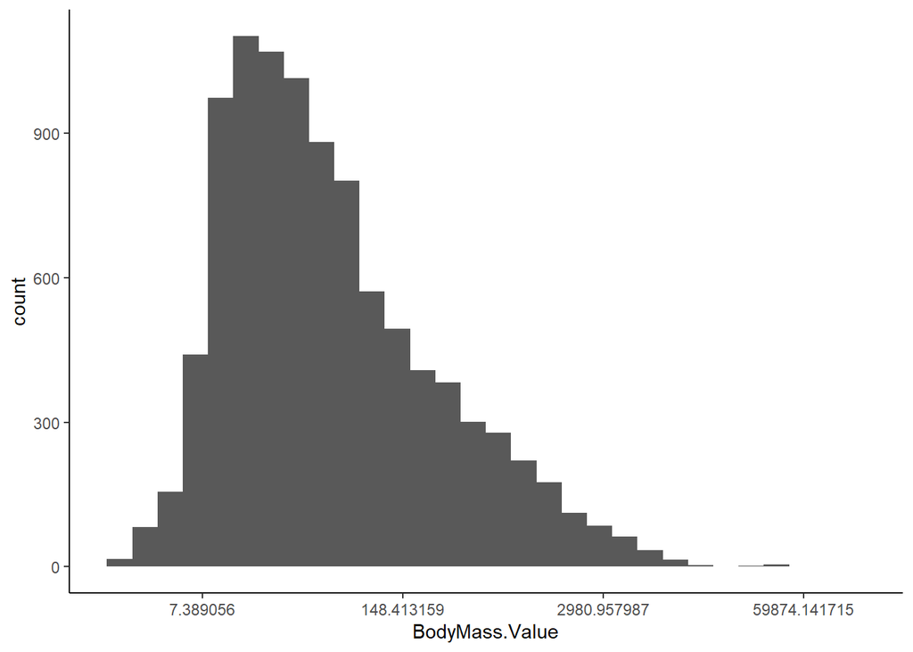

```r
# Log Transformed Body Mass Histogram
ggplot(bird_df, aes(BodyMass.Value)) +
  geom_histogram() +
  scale_x_continuous(trans = "log") +
  theme_classic()
```

Because of the large disparity between large birds, such as ostriches and emus, with a much greater body mass than most birds, the distribution of bodymass is skewed right.

### Pairwise Relationships

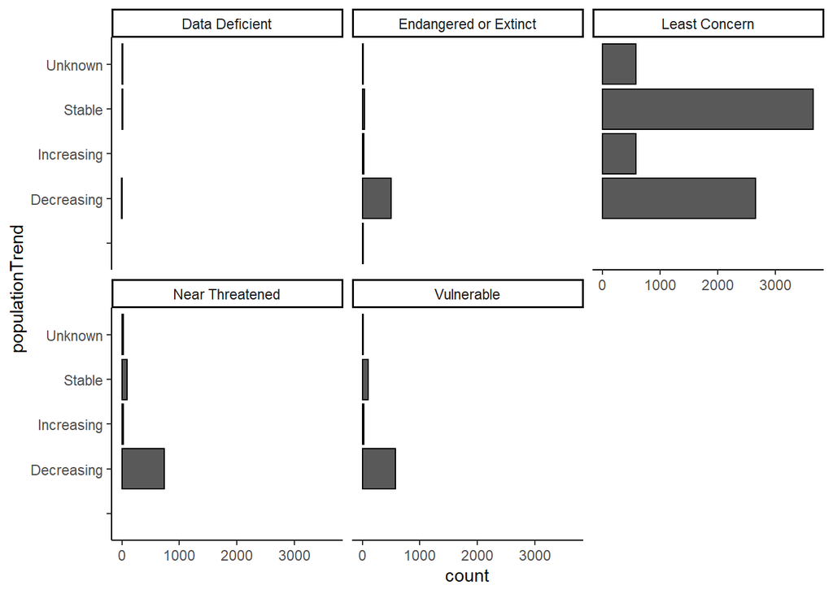

```r
# 1
# Population Trend and Redlist Category Bar Plot
bird_df %>%
  mutate(
    redlistCat2 = case_when(
      redlistCategory == "Critically Endangered" ~ "Endangered or Extinct",
      redlistCategory == "Endangered" ~ "Endangered or Extinct",
      redlistCategory == "Extinct" ~ "Endangered or Extinct",
      redlistCategory == "Extinct in the Wild" ~ "Endangered or Extinct",
      TRUE ~ as.character(redlistCategory)
    )
  ) %>%
  ggplot(aes(populationTrend)) +
    geom_bar(col = "black") +
    facet_wrap(~redlistCat2) +
    coord_flip() +
    theme_classic()
```

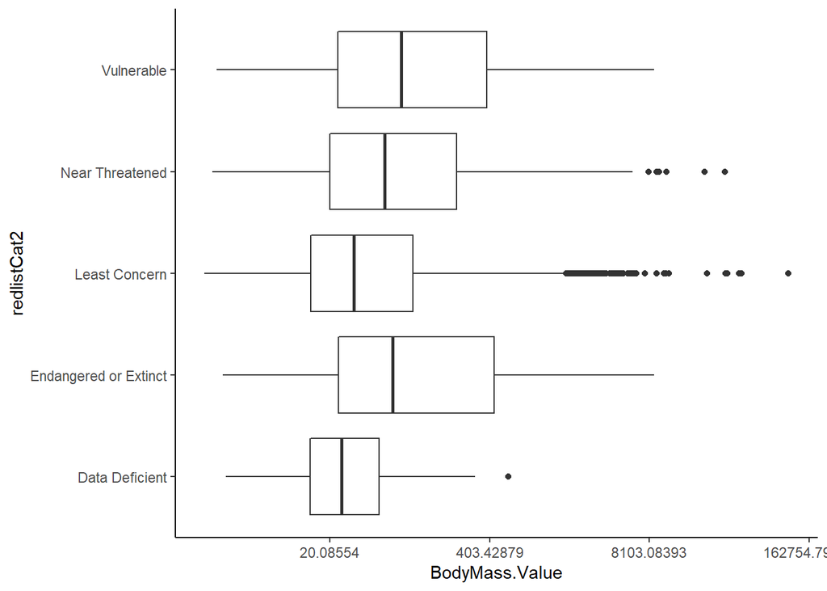

```r
# 2
# Redlist Category vs Body Mass Value Box Plot
bird_df %>%
  mutate(
    redlistCat2 = case_when(
      redlistCategory == "Critically Endangered" ~ "Endangered or Extinct",
      redlistCategory == "Endangered" ~ "Endangered or Extinct",
      redlistCategory == "Extinct" ~ "Endangered or Extinct",
      redlistCategory == "Extinct in the Wild" ~ "Endangered or Extinct",
      TRUE ~ as.character(redlistCategory)
    )
  ) %>%
  ggplot(aes(redlistCat2, BodyMass.Value)) +
    geom_boxplot() +
    coord_flip() +
    scale_y_continuous(trans = "log") +
    theme_classic()
```

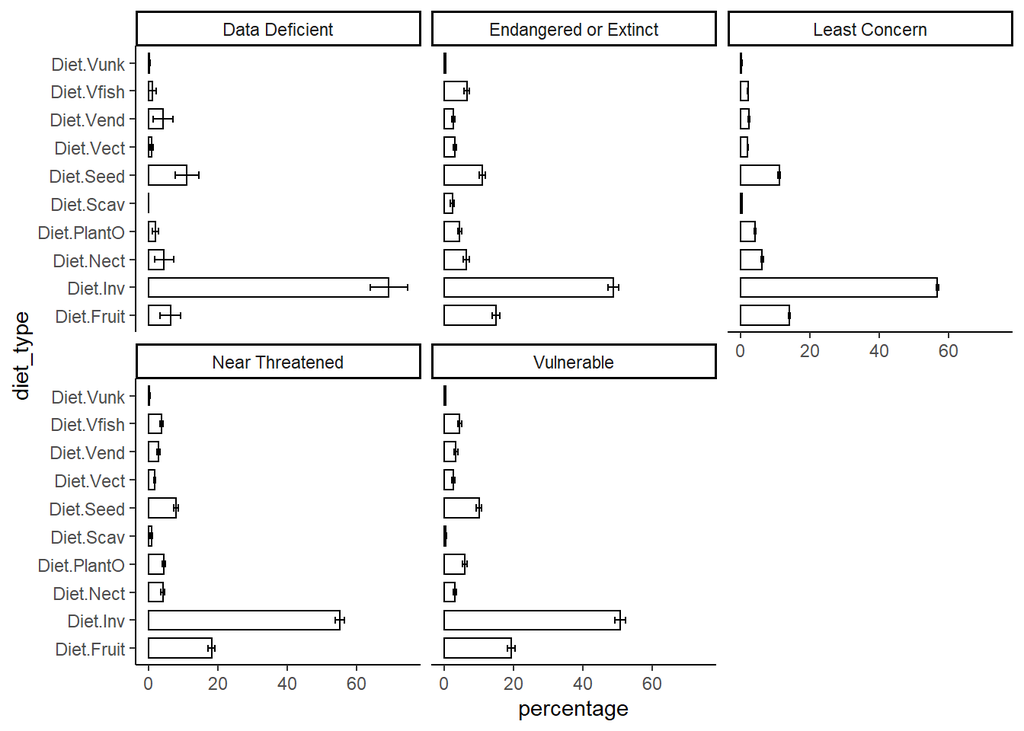

```r
# 3
# Average Diet Percent Use vs Redlist Category Barplots
bird_df %>%
  mutate(
    redlistCat2 = case_when(
      redlistCategory == "Critically Endangered" ~ "Endangered or Extinct",
      redlistCategory == "Endangered" ~ "Endangered or Extinct",
      redlistCategory == "Extinct" ~ "Endangered or Extinct",
      redlistCategory == "Extinct in the Wild" ~ "Endangered or Extinct",
      TRUE ~ as.character(redlistCategory)
    )
  ) %>%
  gather(key = "diet_type", value = "percentage",Diet.Inv, Diet.Vend,
         Diet.Vect, Diet.Vfish, Diet.Vunk, Diet.Scav, Diet.Fruit, Diet.Nect,
         Diet.Seed, Diet.PlantO) %>%
  ggplot(aes(diet_type, percentage)) +
    stat_summary(geom = "bar", fun = mean, position = position_dodge(),
                 colour = "black", fill = "white",
                 width = 0.7) +
    stat_summary(geom = "errorbar", fun.data = mean_se,
                 position = position_dodge(0.7),
                 width = 0.25) +
    facet_wrap(~redlistCat2) +
    coord_flip() +
    theme_classic()
```

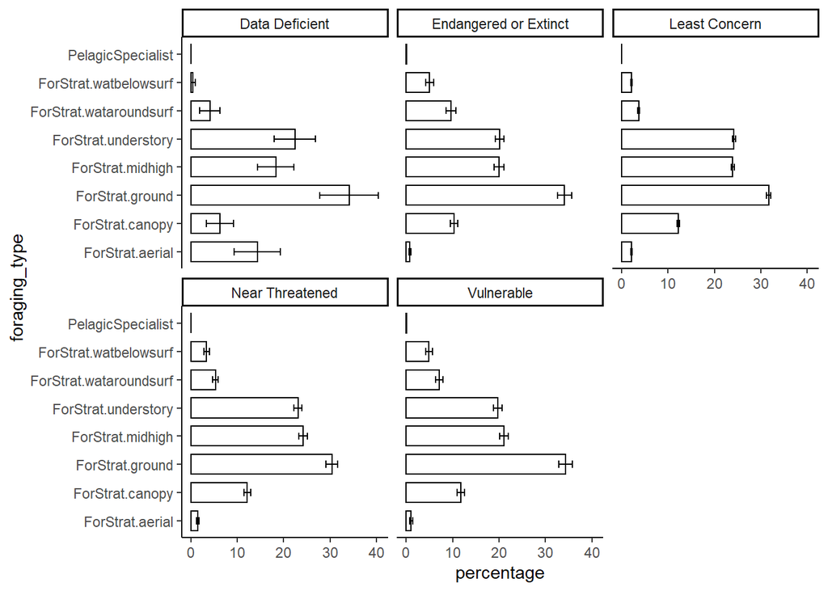

```r
# 4
# Foraging Stratum and Redlist Category Bar Plot
bird_df %>%
  mutate(
    redlistCat2 = case_when(
      redlistCategory == "Critically Endangered" ~ "Endangered or Extinct",
      redlistCategory == "Endangered" ~ "Endangered or Extinct",
      redlistCategory == "Extinct" ~ "Endangered or Extinct",
      redlistCategory == "Extinct in the Wild" ~ "Endangered or Extinct",
      TRUE ~ as.character(redlistCategory)
    )
  ) %>%
  gather(key = "foraging_type", value = "percentage","ForStrat.watbelowsurf" , "ForStrat.wataroundsurf" ,"ForStrat.ground",
 "ForStrat.understory" ,   "ForStrat.midhigh"   ,    "ForStrat.canopy"    ,    "ForStrat.aerial"     ,
  "PelagicSpecialist" ) %>%
  ggplot(aes(foraging_type, percentage)) +
    stat_summary(geom = "bar", fun = mean, position = position_dodge(),
                 colour = "black", fill = "white",
                 width = 0.7) +
    stat_summary(geom = "errorbar", fun.data = mean_se,
                 position = position_dodge(0.7),
                 width = 0.25) +
    facet_wrap(~redlistCat2) +
    coord_flip() +
    theme_classic()
```

1) The majority of endangered or extinct birds (critically endangered, endangered, extinct, and extinct in the wild grouped into one category) have a decreasing population trend. The majority of vulnerable and near threatened birds also have a decreasing population trend. The majority of least concern birds have either a stable population trend or a decreasing population trend.

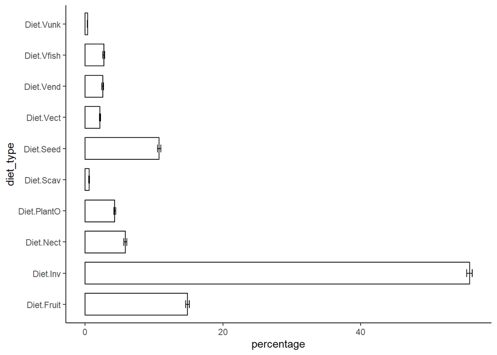

```r
# 5
# Average Percent Use of Each Diet Type
bird_df %>%
  gather(key = "diet_type", value = "percentage", Diet.Inv, Diet.Vend,
         Diet.Vect, Diet.Vfish, Diet.Vunk, Diet.Scav, Diet.Fruit, Diet.Nect,
         Diet.Seed, Diet.PlantO) %>%
  ggplot(aes(diet_type, percentage)) +
    stat_summary(geom = "bar", fun = mean, position = position_dodge(),
                 colour = "black", fill = "white",
                 width = 0.7) +
    stat_summary(geom = "errorbar", fun.data = mean_se,
                 position = position_dodge(0.7),
                 width = 0.25) +
    coord_flip() +
    theme_classic()
```

```r
prop.table(table(bird_df$redlistCategory))*100
```

```
##
## Critically Endangered        Data Deficient            Endangered
##            1.88932480            0.45426389            4.10902333
##               Extinct   Extinct in the Wild         Least Concern
##            0.07226925            0.05162090           77.05967376
##       Near Threatened            Vulnerable
##            9.06462936            7.29919471
```

```r
prop.table(table(bird_df$redlistCategory,bird_df$populationTrend),2)*100
```

```
##
##                                    Decreasing Increasing     Stable    Unknown
##   Critically Endangered  0.0000000  3.2560214  1.5360983  0.3341902  2.1571649
##   Data Deficient         0.0000000  0.2230152  0.0000000  0.3598972  3.0816641
##   Endangered             0.0000000  7.9839429  2.3041475  0.5655527  0.4622496
##   Extinct               58.3333333  0.0000000  0.0000000  0.0000000  0.0000000
##   Extinct in the Wild   41.6666667  0.0000000  0.0000000  0.0000000  0.0000000
##   Least Concern          0.0000000 59.2997324 88.7864823 93.9588689 88.1355932
##   Near Threatened        0.0000000 16.4808207  3.5330261  2.2622108  4.3143297
##   Vulnerable             0.0000000 12.7564674  3.8402458  2.5192802  1.8489985
```

```r
prop.table(table(bird_df$redlistCategory,bird_df$Diet.Inv),2)*100
```

```
##
##                                  0         10         20         30         40
##   Critically Endangered  3.4454471  1.8587361  1.8567639  2.0134228  2.5914634
##   Data Deficient         0.3281378  0.1239157  0.1326260  0.6711409  0.1524390
##   Endangered             5.6603774  4.8327138  3.7135279  3.5234899  3.8109756
##   Extinct                0.0000000  0.0000000  0.1326260  0.1677852  0.0000000
##   Extinct in the Wild    0.1640689  0.1239157  0.0000000  0.1677852  0.0000000
##   Least Concern         66.2838392 79.3060719 78.3819629 79.5302013 77.2865854
##   Near Threatened       12.0590648  8.5501859  8.3554377  6.3758389  8.5365854
##   Vulnerable            12.0590648  5.2044610  7.4270557  7.5503356  7.6219512
##
##                                 50         60         70         80         90
##   Critically Endangered  1.7218543  0.8403361  1.5533981  2.0000000  2.1897810
##   Data Deficient         0.6622517  0.4201681  0.1941748  0.3750000  0.4866180
##   Endangered             5.1655629  4.4117647  5.4368932  2.8750000  3.8929440
##   Extinct                0.0000000  0.0000000  0.0000000  0.1250000  0.2433090
##   Extinct in the Wild    0.0000000  0.0000000  0.0000000  0.1250000  0.0000000
##   Least Concern         75.7615894 85.0840336 76.6990291 82.8750000 78.3454988
##   Near Threatened        8.8741722  5.0420168  9.9029126  6.5000000  9.7323601
##   Vulnerable             7.8145695  4.2016807  6.2135922  5.1250000  5.1094891
##
##                                100
##   Critically Endangered  1.2244898
##   Data Deficient         0.7421150
##   Endangered             3.3024119
##   Extinct                0.1113173
##   Extinct in the Wild    0.0000000
##   Least Concern         77.3654917
##   Near Threatened       10.0556586
##   Vulnerable             7.1985158
```

```r
prop.table(table(bird_df$redlistCategory,bird_df$Diet.Nect),2)*100
```

```
##
##                                   0          10          20          30
##   Critically Endangered  1.90487459  0.94936709  0.61349693  0.00000000
##   Data Deficient         0.47326077  0.31645570  0.00000000  0.81967213
##   Endangered             4.20018930  3.48101266  3.68098160  1.63934426
##   Extinct                0.07098912  0.00000000  0.61349693  0.00000000
##   Extinct in the Wild    0.04732608  0.31645570  0.00000000  0.00000000
##   Least Concern         76.05300521 83.54430380 84.04907975 91.80327869
##   Near Threatened        9.42972078  7.59493671  8.58895706  2.45901639
##   Vulnerable             7.82063417  3.79746835  2.45398773  3.27868852
##
##                                  40          50          60          70
##   Critically Endangered  0.00000000  2.56410256  4.44444444  5.71428571
##   Data Deficient         0.00000000  0.00000000  2.22222222  0.00000000
##   Endangered             2.81690141  1.70940171  4.44444444  0.00000000
##   Extinct                0.00000000  0.00000000  0.00000000  0.00000000
##   Extinct in the Wild    0.00000000  0.00000000  0.00000000  0.00000000
##   Least Concern         88.73239437 82.90598291 77.77777778 85.71428571
##   Near Threatened        1.40845070  8.54700855  6.66666667  5.71428571
##   Vulnerable             7.04225352  4.27350427  4.44444444  2.85714286
##
##                                  80          90         100
##   Critically Endangered  4.16666667  2.63157895  5.71428571
##   Data Deficient         0.00000000  0.00000000  2.85714286
##   Endangered             0.00000000  3.94736842 17.14285714
##   Extinct                0.00000000  0.00000000  0.00000000
##   Extinct in the Wild    0.00000000  0.00000000  0.00000000
##   Least Concern         79.16666667 85.85526316 45.71428571
##   Near Threatened        0.00000000  5.92105263 17.14285714
##   Vulnerable            16.66666667  1.64473684 11.42857143
```

```r
prop.table(table(bird_df$redlistCategory,bird_df$Nocturnal),2)*100
```

```
##
##                                   0           1
##   Critically Endangered  1.92287149  0.92879257
##   Data Deficient         0.41662216  1.54798762
##   Endangered             4.10212584  4.33436533
##   Extinct                0.07477834  0.00000000
##   Extinct in the Wild    0.05341310  0.00000000
##   Least Concern         77.14987715 74.30340557
##   Near Threatened        9.02681337 10.21671827
##   Vulnerable             7.25349856  8.66873065
```

```r
prop.table(table(bird_df$redlistCategory,bird_df$PelagicSpecialist),2)*100
```

```
##
##                                   0           1
##   Critically Endangered  1.78476575  5.53505535
##   Data Deficient         0.45681504  0.36900369
##   Endangered             3.87761606 12.17712177
##   Extinct                0.07436524  0.00000000
##   Extinct in the Wild    0.05311803  0.00000000
##   Least Concern         77.81791140 50.55350554
##   Near Threatened        8.94507596 13.28413284
##   Vulnerable             6.99033252 18.08118081
```

```r
#Deciding which ones to include based on whether different redlistcategories have different percentages in each percentage of variable

prop.table(table(bird_df$redlistCategory,bird_df$ForStrat.watbelowsurf),2)*100 #include in model
```

```
##
##                                   0          10          20          30
##   Critically Endangered  1.80936995  0.00000000  8.04597701  0.00000000
##   Data Deficient         0.46311255  0.00000000  1.14942529  0.00000000
##   Endangered             3.90953150 14.28571429 11.49425287 14.28571429
##   Extinct                0.07539041  0.00000000  0.00000000  0.00000000
##   Extinct in the Wild    0.05385030  0.00000000  0.00000000  0.00000000
##   Least Concern         77.66289715 76.19047619 56.32183908 71.42857143
##   Near Threatened        8.97145934  4.76190476  8.04597701 14.28571429
##   Vulnerable             7.05438880  4.76190476 14.94252874  0.00000000
##
##                                  40          50          60          70
##   Critically Endangered  0.00000000  0.00000000  0.00000000  5.26315789
##   Data Deficient         0.00000000  0.00000000  0.00000000  0.00000000
##   Endangered             4.00000000  3.12500000 11.11111111  0.00000000
##   Extinct                0.00000000  0.00000000  0.00000000  0.00000000
##   Extinct in the Wild    0.00000000  0.00000000  0.00000000  0.00000000
##   Least Concern         72.00000000 56.25000000 77.77777778 68.42105263
##   Near Threatened       16.00000000 18.75000000 11.11111111 10.52631579
##   Vulnerable             8.00000000 21.87500000  0.00000000 15.78947368
##
##                                  80          90         100
##   Critically Endangered  2.63157895  0.00000000  4.08163265
##   Data Deficient         0.00000000  0.00000000  0.00000000
##   Endangered             5.26315789  0.00000000 10.20408163
##   Extinct                0.00000000  0.00000000  0.00000000
##   Extinct in the Wild    0.00000000  0.00000000  0.00000000
##   Least Concern         73.68421053 85.71428571 58.50340136
##   Near Threatened       10.52631579  0.00000000 12.24489796
##   Vulnerable             7.89473684 14.28571429 14.96598639
```

```r
prop.table(table(bird_df$redlistCategory,bird_df$ForStrat.wataroundsurf),2)*100 # include in model
```

```
##
##                                   0          10          20          30
##   Critically Endangered  1.73697270  3.92156863  2.43902439  3.17460317
##   Data Deficient         0.43988270  1.96078431  1.21951220  0.00000000
##   Endangered             3.81231672  1.96078431  4.26829268  3.17460317
##   Extinct                0.07895330  0.00000000  0.00000000  0.00000000
##   Extinct in the Wild    0.05639522  0.00000000  0.00000000  0.00000000
##   Least Concern         77.94946988 74.50980392 74.39024390 76.19047619
##   Near Threatened        8.93300248  7.84313725 10.97560976  6.34920635
##   Vulnerable             6.99300699  9.80392157  6.70731707 11.11111111
##
##                                  40          50          60          70
##   Critically Endangered  3.07692308  1.69491525  6.45161290  0.00000000
##   Data Deficient         0.00000000  0.56497175  0.00000000  0.00000000
##   Endangered             4.61538462  7.90960452  9.67741935  3.84615385
##   Extinct                0.00000000  0.00000000  0.00000000  0.00000000
##   Extinct in the Wild    0.00000000  0.00000000  0.00000000  0.00000000
##   Least Concern         73.84615385 66.66666667 58.06451613 76.92307692
##   Near Threatened       15.38461538 10.16949153  9.67741935 11.53846154
##   Vulnerable             3.07692308 12.99435028 16.12903226  7.69230769
##
##                                  80          90         100
##   Critically Endangered  5.00000000  0.00000000  6.87022901
##   Data Deficient         1.00000000  0.00000000  0.00000000
##   Endangered            12.00000000 30.00000000 10.68702290
##   Extinct                0.00000000  0.00000000  0.00000000
##   Extinct in the Wild    0.00000000  0.00000000  0.00000000
##   Least Concern         60.00000000 60.00000000 55.72519084
##   Near Threatened        8.00000000  0.00000000 13.74045802
##   Vulnerable            14.00000000 10.00000000 12.97709924
```

```r
prop.table(table(bird_df$redlistCategory,bird_df$ForStrat.ground),2)*100 #even across all categories so not including in model
```

```
##
##                                   0          10          20          25
##   Critically Endangered  1.71159606  2.39726027  2.35081374  0.00000000
##   Data Deficient         0.51347882  0.00000000  0.36166365  0.00000000
##   Endangered             3.85109114  4.10958904  5.42495479  0.00000000
##   Extinct                0.06418485  0.00000000  0.00000000  0.00000000
##   Extinct in the Wild    0.02139495  0.00000000  0.18083183  0.00000000
##   Least Concern         77.32135216 78.42465753 75.04520796 76.66666667
##   Near Threatened        9.56354300  8.56164384  8.49909584 16.66666667
##   Vulnerable             6.95335901  6.50684932  8.13743219  6.66666667
##
##                                  30          33          40          50
##   Critically Endangered  2.83400810  0.74074074  2.22929936  1.51133501
##   Data Deficient         0.00000000  0.00000000  0.63694268  0.12594458
##   Endangered             2.42914980  2.96296296  5.41401274  3.90428212
##   Extinct                0.00000000  0.00000000  0.00000000  0.00000000
##   Extinct in the Wild    0.00000000  0.00000000  0.00000000  0.12594458
##   Least Concern         78.13765182 80.00000000 74.84076433 80.73047859
##   Near Threatened        7.28744939 10.37037037  8.28025478  8.31234257
##   Vulnerable             9.31174089  5.92592593  8.59872611  5.28967254
##
##                                  60          70          80          90
##   Critically Endangered  2.09424084  1.16731518  1.58730159  2.47933884
##   Data Deficient         0.26178010  0.77821012  0.59523810  0.82644628
##   Endangered             5.49738220  6.61478599  4.96031746  2.47933884
##   Extinct                0.00000000  0.00000000  0.39682540  0.00000000
##   Extinct in the Wild    0.00000000  0.38910506  0.00000000  0.00000000
##   Least Concern         76.43979058 72.37354086 77.38095238 76.85950413
##   Near Threatened        8.11518325  9.72762646  9.12698413  6.61157025
##   Vulnerable             7.59162304  8.94941634  5.95238095 10.74380165
##
##                                 100
##   Critically Endangered  2.46198407
##   Data Deficient         0.57929037
##   Endangered             3.76538740
##   Extinct                0.14482259
##   Extinct in the Wild    0.07241130
##   Least Concern         75.52498190
##   Near Threatened        8.68935554
##   Vulnerable             8.76176684
```

```r
prop.table(table(bird_df$redlistCategory,bird_df$ForStrat.understory),2)*100 #pretty even across categories, not including
```

```
##
##                                   0          10          20          25
##   Critically Endangered  2.32738557  0.55350554  1.93648335  0.00000000
##   Data Deficient         0.56891647  0.36900369  0.46475600  0.00000000
##   Endangered             4.55133178  3.13653137  3.87296669  2.77777778
##   Extinct                0.05171968  0.00000000  0.15491867  0.00000000
##   Extinct in the Wild    0.05171968  0.36900369  0.07745933  0.00000000
##   Least Concern         74.45047841 81.36531365 75.60030984 72.22222222
##   Near Threatened        9.49056116  6.27306273 10.53446940 19.44444444
##   Vulnerable             8.50788725  7.93357934  7.35863672  5.55555556
##
##                                  30          33          40          50
##   Critically Endangered  2.40963855  1.15606936  2.03193033  1.29198966
##   Data Deficient         0.12048193  0.57803468  0.00000000  0.25839793
##   Endangered             5.06024096  3.75722543  5.07982583  3.18690784
##   Extinct                0.00000000  0.00000000  0.00000000  0.17226529
##   Extinct in the Wild    0.00000000  0.00000000  0.00000000  0.00000000
##   Least Concern         77.83132530 79.47976879 78.66473149 80.96468562
##   Near Threatened        7.71084337  9.24855491  7.98258345  8.44099914
##   Vulnerable             6.86746988  5.78034682  6.24092888  5.68475452
##
##                                  60          70          80          90
##   Critically Endangered  0.46948357  3.72670807  1.18110236  0.00000000
##   Data Deficient         1.87793427  0.00000000  0.78740157  0.00000000
##   Endangered             4.69483568  3.72670807  0.78740157 10.00000000
##   Extinct                0.46948357  0.00000000  0.00000000  0.00000000
##   Extinct in the Wild    0.00000000  0.00000000  0.00000000  0.00000000
##   Least Concern         78.87323944 78.88198758 83.07086614 70.00000000
##   Near Threatened        7.51173709 10.55900621  7.08661417 15.00000000
##   Vulnerable             6.10328638  3.10559006  7.08661417  5.00000000
##
##                                 100
##   Critically Endangered  0.72992701
##   Data Deficient         0.72992701
##   Endangered             2.55474453
##   Extinct                0.00000000
##   Extinct in the Wild    0.00000000
##   Least Concern         79.19708029
##   Near Threatened       11.31386861
##   Vulnerable             5.47445255
```

```r
prop.table(table(bird_df$redlistCategory,bird_df$ForStrat.midhigh),2)*100 #pretty even across categories, not including
```

```
##
##                                   0          10          20          25
##   Critically Endangered  2.15259507  1.28534704  1.94444444  0.00000000
##   Data Deficient         0.55010763  1.02827763  0.27777778  0.00000000
##   Endangered             4.68787371  4.62724936  3.70370370  2.56410256
##   Extinct                0.09567089  0.00000000  0.00000000  0.00000000
##   Extinct in the Wild    0.02391772  0.00000000  0.18518519  0.00000000
##   Least Concern         75.29299211 75.32133676 79.72222222 69.23076923
##   Near Threatened        9.13657020  9.76863753  7.87037037 20.51282051
##   Vulnerable             8.06027266  7.96915167  6.29629630  7.69230769
##
##                                  30          33          40          50
##   Critically Endangered  2.76967930  1.07526882  1.61290323  1.46892655
##   Data Deficient         0.29154519  0.53763441  0.49627792  0.22598870
##   Endangered             4.22740525  3.49462366  3.34987593  3.50282486
##   Extinct                0.00000000  0.00000000  0.12406948  0.22598870
##   Extinct in the Wild    0.00000000  0.00000000  0.12406948  0.00000000
##   Least Concern         78.13411079 77.95698925 79.15632754 77.51412429
##   Near Threatened        7.87172012 11.02150538  8.80893300  8.13559322
##   Vulnerable             6.70553936  5.91397849  6.32754342  8.92655367
##
##                                  60          70          80          90
##   Critically Endangered  1.96463654  1.79372197  0.36630037  0.00000000
##   Data Deficient         0.19646365  0.00000000  0.73260073  0.00000000
##   Endangered             4.51866405  2.69058296  2.93040293  0.00000000
##   Extinct                0.00000000  0.00000000  0.00000000  0.00000000
##   Extinct in the Wild    0.19646365  0.00000000  0.00000000  0.00000000
##   Least Concern         76.22789784 84.30493274 81.68498168 74.35897436
##   Near Threatened        9.82318271  7.62331839 10.25641026 17.94871795
##   Vulnerable             7.07269155  3.58744395  4.02930403  7.69230769
##
##                                 100
##   Critically Endangered  1.48514851
##   Data Deficient         0.49504950
##   Endangered             2.97029703
##   Extinct                0.00000000
##   Extinct in the Wild    0.00000000
##   Least Concern         76.73267327
##   Near Threatened       12.37623762
##   Vulnerable             5.94059406
```

```r
prop.table(table(bird_df$redlistCategory,bird_df$ForStrat.canopy),2)*100 # moderately even
```

```
##
##                                   0          10          20          25
##   Critically Endangered  1.90677966  2.27272727  2.31607629  0.00000000
##   Data Deficient         0.57506053  0.00000000  0.27247956  0.00000000
##   Endangered             4.29782082  3.89610390  4.90463215  2.63157895
##   Extinct                0.10593220  0.00000000  0.00000000  0.00000000
##   Extinct in the Wild    0.03026634  0.00000000  0.27247956  0.00000000
##   Least Concern         76.64951574 78.89610390 75.34059946 68.42105263
##   Near Threatened        8.91343826  9.09090909 10.21798365 21.05263158
##   Vulnerable             7.52118644  5.84415584  6.67574932  7.89473684
##
##                                  30          33          40          50
##   Critically Endangered  2.25733634  1.25000000  1.77777778  1.81818182
##   Data Deficient         0.00000000  0.83333333  0.00000000  0.00000000
##   Endangered             2.93453725  3.75000000  3.11111111  1.81818182
##   Extinct                0.00000000  0.00000000  0.00000000  0.00000000
##   Extinct in the Wild    0.00000000  0.00000000  0.22222222  0.00000000
##   Least Concern         79.90970655 75.41666667 76.44444444 85.90909091
##   Near Threatened        8.57787810 12.91666667  9.77777778  4.54545455
##   Vulnerable             6.32054176  5.83333333  8.66666667  5.90909091
##
##                                  60          70          80          90
##   Critically Endangered  1.38248848  2.43902439  0.49261084  6.66666667
##   Data Deficient         0.00000000  0.81300813  0.00000000  0.00000000
##   Endangered             4.14746544  5.69105691  2.95566502  6.66666667
##   Extinct                0.00000000  0.00000000  0.00000000  0.00000000
##   Extinct in the Wild    0.00000000  0.00000000  0.00000000  0.00000000
##   Least Concern         81.56682028 74.79674797 82.75862069 66.66666667
##   Near Threatened        7.37327189  6.50406504  9.35960591  0.00000000
##   Vulnerable             5.52995392  9.75609756  4.43349754 20.00000000
##
##                                 100
##   Critically Endangered  0.00000000
##   Data Deficient         1.17647059
##   Endangered             2.35294118
##   Extinct                0.00000000
##   Extinct in the Wild    0.00000000
##   Least Concern         70.58823529
##   Near Threatened       14.11764706
##   Vulnerable            11.76470588
```

```r
prop.table(table(bird_df$redlistCategory,bird_df$ForStrat.aerial),2)*100 #very high proportion in least concern, including
```

```
##
##                                   0          10          20          25
##   Critically Endangered  1.95905789  0.85106383  1.50375940  0.00000000
##   Data Deficient         0.39621396  0.42553191  0.00000000  0.00000000
##   Endangered             4.22628219  2.97872340  1.50375940 20.00000000
##   Extinct                0.07704160  0.00000000  0.00000000  0.00000000
##   Extinct in the Wild    0.05502972  0.00000000  0.00000000  0.00000000
##   Least Concern         76.55734096 86.38297872 86.46616541 40.00000000
##   Near Threatened        9.18996258  6.80851064  6.01503759 40.00000000
##   Vulnerable             7.53907110  2.55319149  4.51127820  0.00000000
##
##                                  30          33          40          50
##   Critically Endangered  0.00000000  0.00000000  0.00000000  0.00000000
##   Data Deficient         0.00000000  0.00000000  0.00000000  0.00000000
##   Endangered             4.16666667  0.00000000  7.14285714  0.00000000
##   Extinct                0.00000000  0.00000000  0.00000000  0.00000000
##   Extinct in the Wild    0.00000000  0.00000000  0.00000000  0.00000000
##   Least Concern         83.33333333 73.07692308 71.42857143 93.75000000
##   Near Threatened        8.33333333 19.23076923  7.14285714  6.25000000
##   Vulnerable             4.16666667  7.69230769 14.28571429  0.00000000
##
##                                  60          70          80          90
##   Critically Endangered  0.00000000  0.00000000  0.00000000  0.00000000
##   Data Deficient         5.55555556  6.66666667  0.00000000  7.14285714
##   Endangered             0.00000000  0.00000000  4.54545455  0.00000000
##   Extinct                0.00000000  0.00000000  0.00000000  0.00000000
##   Extinct in the Wild    0.00000000  0.00000000  0.00000000  0.00000000
##   Least Concern         88.88888889 86.66666667 90.90909091 85.71428571
##   Near Threatened        0.00000000  6.66666667  4.54545455  7.14285714
##   Vulnerable             5.55555556  0.00000000  0.00000000  0.00000000
##
##                                 100
##   Critically Endangered  1.92307692
##   Data Deficient         7.69230769
##   Endangered             0.00000000
##   Extinct                0.00000000
##   Extinct in the Wild    0.00000000
##   Least Concern         78.84615385
##   Near Threatened        5.76923077
##   Vulnerable             5.76923077
```

```r
sapply(split(bird_df$BodyMass.Value,bird_df$redlistCategory),mean)
```

```
## Critically Endangered        Data Deficient            Endangered
##             718.60393              56.75068             558.76266
##               Extinct   Extinct in the Wild         Least Concern
##              96.55429             764.69800                    NA
##       Near Threatened            Vulnerable
##             425.27017             508.20260
```

```r
sapply(split(bird_df$BodyMass.Value,bird_df$redlistCategory),length)
```

```
## Critically Endangered        Data Deficient            Endangered
##                   183                    44                   398
##               Extinct   Extinct in the Wild         Least Concern
##                     7                     5                  7464
##       Near Threatened            Vulnerable
##                   878                   707
```

# Modeling

Types of models to use:

Classification models only (could convert classes to numeric 1 thru 4, but makes our prediction undesirable, plus not equal jumps between classes)

1. Logistic Regression (pairwise/one-versus-one and one-versus-all)?
2. Linear Discriminant Analysis
3. Quadratic Discriminant Analysis
4. K-Nearest Neighbor
5. Classification Tree
6. Bagged Trees
7. Random Forests
8. Boosted Forests
9. Neural Networks
10. Support Vector Machines

Additional Considerations for Modeling

1. PCA of all diet and foraging variables a. All diet variables are highly correlated, because they each sum up to 100. Thus, using PCA could really simplify the models considerably b. Additionally, if PCA is performed on diet variables then the diet variables should not be scaled because they already are by nature of the data

```r
library(tidyverse)
library(class)
library(tree)
library(randomForest)
library(MASS)
library(e1071)
library(nnet)
library(gbm)
```

```r
mammal_df = read.csv("cleaned_mammal_df.csv")
bird_df = read.csv("cleaned_bird_df_updated_5_29.csv")
```

```r
nrow(bird_df)
```

```
## [1] 9686
```

```r
bird_df = bird_df[1:9640,]
```

# Preparing Data

## Transforming Variables

```r
# Converting mammal activity variables to factors
mammal_df$Activity.Nocturnal = as.factor(mammal_df$Activity.Nocturnal)
mammal_df$Activity.Crepuscular = as.factor(mammal_df$Activity.Crepuscular)
mammal_df$Activity.Diurnal = as.factor(mammal_df$Activity.Diurnal)
mammal_df$redlistCategory = as.factor(mammal_df$redlistCategory)

# Converting bird activity variables to factors
bird_df$Nocturnal = as.factor(bird_df$Nocturnal)
bird_df$redlistCategory = as.factor(bird_df$redlistCategory)
```

```r
# Combine "Extinct" & "Extinct in the Wild" & "Critically Endangered" into "Endangered"
mammal_df$redlistCategory = as.character(car::recode(mammal_df$redlistCategory,recodes = "'Extinct'='Endangered';'Extinct in the Wild'='Endangered';'Critically Endangered'='Endangered'"))

bird_df$redlistCategory = as.character(car::recode(bird_df$redlistCategory,recodes = "'Extinct'='Endangered';'Extinct in the Wild'='Endangered';'Critically Endangered'='Endangered'"))
```

```r
# Mammal Explanatory Variable Transformations
mammal_df = mammal_df %>%
  mutate(
    log_bodymass = log(BodyMass.Value)
  )


# Bird Explanatory Variable Transformations

bird_df = bird_df %>%
  mutate(
    log_bodymass = log(BodyMass.Value)
  )
```

## Adding PCA of Diet and Foraging

Creating data frames with Principle Components as columns

```r
pcbirddiet = prcomp(bird_df[,c(12:21)],scale=FALSE)

pcbirdforage = prcomp(bird_df[,c(26:32)],scale=FALSE)

pcmammal = prcomp(mammal_df[,c(4:13)],scale = FALSE)

pcbird = prcomp(bird_df[,c(12:21,26:32)],scale=FALSE)

summary(pcmammal)
```

```
## Importance of components:
##                            PC1     PC2      PC3      PC4      PC5     PC6
## Standard deviation     47.5094 30.7692 18.30169 15.15549 10.55199 9.40074
## Proportion of Variance  0.5512  0.2312  0.08179  0.05609  0.02719 0.02158
## Cumulative Proportion   0.5512  0.7823  0.86413  0.92022  0.94741 0.96899
##                            PC7     PC8     PC9    PC10
## Standard deviation     8.64490 5.40228 4.74033 0.78303
## Proportion of Variance 0.01825 0.00713 0.00549 0.00015
## Cumulative Proportion  0.98724 0.99436 0.99985 1.00000
```

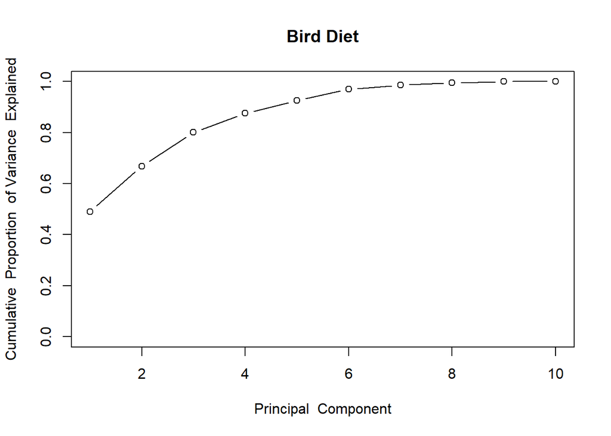

```r
plot(cumsum(pcbirddiet$sdev^2/sum(pcbirddiet$sdev^2)), xlab="Principal  Component", ylab="Cumulative  Proportion  of Variance  Explained", ylim=c(0,1),type="b",main = "Bird Diet")
```

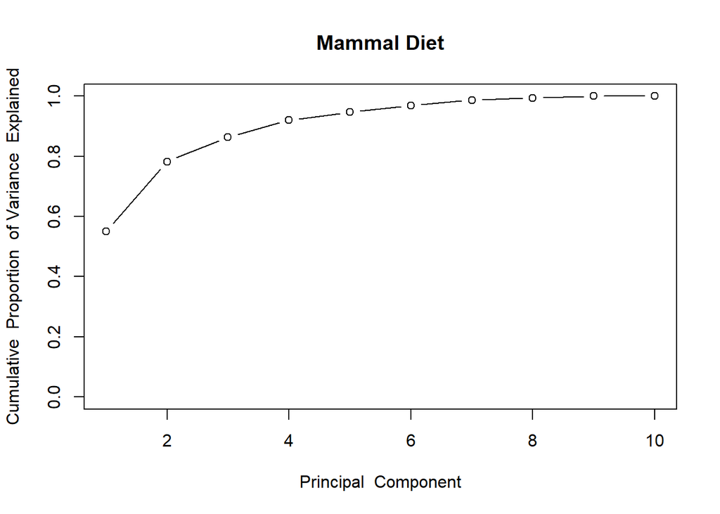

```r
plot(cumsum(pcmammal$sdev^2/sum(pcmammal$sdev^2)), xlab="Principal  Component", ylab="Cumulative  Proportion  of Variance  Explained", ylim=c(0,1),type="b",main = "Mammal Diet")
```

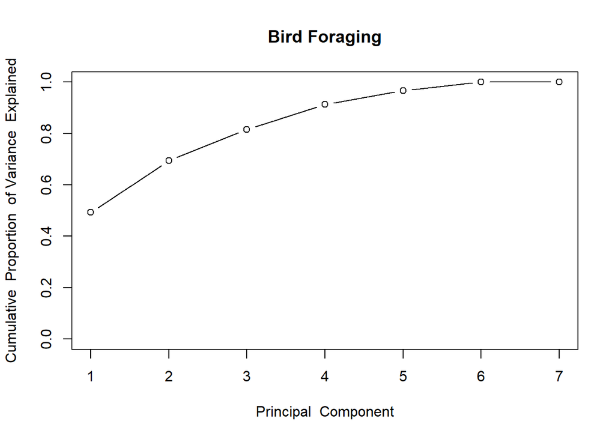

```r
plot(cumsum(pcbirdforage$sdev^2/sum(pcbirdforage$sdev^2)), xlab="Principal  Component", ylab="Cumulative  Proportion  of Variance  Explained", ylim=c(0,1),type="b",main = "Bird Foraging")
```

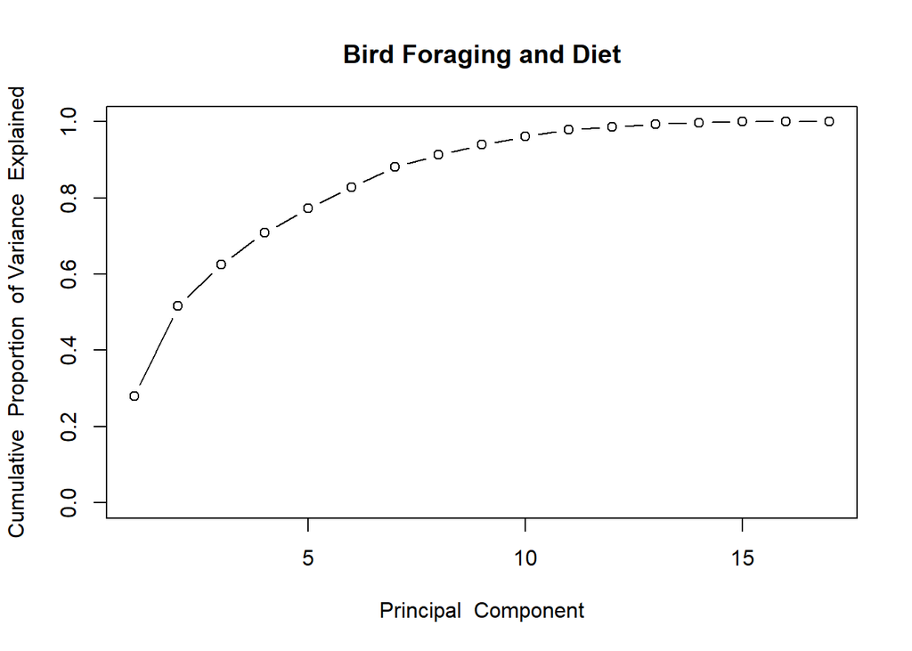

```r
plot(cumsum(pcbird$sdev^2/sum(pcbird$sdev^2)), xlab="Principal  Component", ylab="Cumulative  Proportion  of Variance  Explained", ylim=c(0,1),type="b",main = "Bird Foraging and Diet")
```

```r
colnames(pcbirddiet$x) = paste("Diet",colnames(pcbirddiet$x),sep = "")

colnames(pcmammal$x) = paste("Diet",colnames(pcmammal$x),sep = "")

colnames(pcbirdforage$x) = paste("For",colnames(pcbirdforage$x),sep = "")

colnames(pcbird$x) = paste("DietFor",colnames(pcbird$x),sep = "")

bird_df = cbind(bird_df,
                   cbind(pcbirddiet$x,
                         cbind(pcbirdforage$x,pcbird$x)))

mammal_df = cbind(mammal_df,pcmammal$x)

remove(pcbird,pcbirddiet,pcbirdforage,pcmammal)
```

## Making Training and Test Datasets

```r
# Moving data deficient mammals to different data set
data_deficient_mammals_df = mammal_df[mammal_df$redlistCategory == "Data Deficient",]
# Removing data deficient mammals
mammal_df = mammal_df[mammal_df$redlistCategory != "Data Deficient",]

# Moving data def birds to different dataset
data_deficient_birds_df = bird_df[bird_df$redlistCategory == "Data Deficient",]
# Removing data deficient birds
bird_df = bird_df[bird_df$redlistCategory != "Data Deficient",]
```

```r
# Creating indices for training sets
set.seed(10)
train_mammal = sample(1:nrow(mammal_df), size = round(nrow(mammal_df)/2))
train_bird = sample(1:nrow(bird_df), size = round(nrow(bird_df)/2))

# Creating training and test sets
mammal_train_df = mammal_df[train_mammal,]
mammal_test_df = mammal_df[-train_mammal,]

bird_train_df = bird_df[train_bird,]
bird_test_df = bird_df[-train_bird,]
```

# 1: Logistic Regression

## Mammal Logistic Regression

### Format Variables

```r
# Create separate logistic regression dataframe
mammals_log_train_df = mammal_train_df
mammals_log_test_df = mammal_test_df

# Change Response to Binary
mammals_log_train_df = mammals_log_train_df %>%
  mutate(
    redlistCategory = case_when(
      redlistCategory == "Endangered" ~ 1,
      redlistCategory == "Near Threatened" ~ 1,
      redlistCategory == "Vulnerable" ~ 1,
      TRUE ~ 0
    )
  )

mammals_log_test_df = mammals_log_test_df %>%
  mutate(
    redlistCategory = case_when(
      redlistCategory == "Endangered" ~ 1,
      redlistCategory == "Near Threatened" ~ 1,
      redlistCategory == "Vulnerable" ~ 1,
      TRUE ~ 0
    )
  )
```

### Variable Selection

```r
mammal_log_variables = list(c(38,4, 5, 6, 7, 8, 9, 10, 11, 12, 13), #all diet variables
                            c(38,7, 9, 10, 11, 12, 13),                  #selected diet variables
                            c(38,41),                               #log body mass
                            c(38,19, 20, 21, 41),                   #activity and body mass
                            c(38,4, 5, 6, 7, 8, 9, 10, 11, 12, 13, 19, 20, 21), #all diet and activity variables
                            c(38,4, 5, 6, 7, 8, 9, 10, 11, 12, 13, 41),         #all diet and body mass
                            c(38,41, 4, 5, 6, 7, 8, 9, 10, 11, 12, 13, 19, 20, 21), #all diet and activity and body mass
                            c(38,7, 9, 10, 11, 12, 13, 41), #selected activity variables and body mass
                            c(38,7, 9, 10, 11, 12, 13, 19, 20, 21), #selected diet and activity
                            c(38,7, 9, 10, 11, 12, 13, 19, 20, 21, 41), #selected diet, activity and body mass
                            c(38,42, 43, 44, 45, 46, 47, 48), # 7 PC for diet
                            c(38,42, 43, 44, 45, 46, 47, 48, 41), # PCA for diet and diet
                            c(38,42, 43, 44, 45, 46, 47, 48, 19, 20, 21), # PCA for diet and activity
                            c(38,42, 43, 44, 45, 46, 47, 48, 19, 20, 21, 41), # PCA for diet, activity, and body mass
                            c(38,7, 9, 10, 11, 12, 13, 16),     #selected diet variables and foraging
                            c(38,7, 9, 10, 11, 12, 13, 41, 16), #selected activity variables and body mass and foraging
                            c(38, 16, 19, 20, 21), # activity and foraging
                            c(38, 16, 42, 43, 44, 45, 46, 47, 48, 41),   # PCA for diet, and body mass and foraging
                            c(38, 16, 42, 43, 44, 45, 46, 47, 48, 19, 20, 21, 41), #PCAdiet, and activity, body mass, and foraging
                            c(38,7, 9, 10, 11, 12, 13, 19, 20, 21, 41, 16)#selected diet, activity and body mass and foraging

                            )
```

```r
test_errors = rep(0, length(mammal_log_variables))

for(i in 1:length(mammal_log_variables)){
  var = mammal_log_variables[[i]]
  mammal_log = glm(redlistCategory ~ .,
                   data = mammals_log_train_df[,var])
  log_prob = predict(mammal_log, newdata=mammals_log_test_df[,var], type = "response")
  log_pred = rep(0, 2146)
  log_pred[log_prob > 0.5] = 1
  test_errors[i] = mean(log_pred != mammals_log_test_df$redlistCategory)
}

which.min(test_errors)
mammal_log_variables[[which.min(test_errors)]]

# Best Variables: Selected diet variables, bodymass, and foraging
```

### Best Model

```r
var = mammal_log_variables[[16]]
mammal_log = glm(redlistCategory ~ .,
                   data = mammals_log_train_df[,var])
log_prob = predict(mammal_log, newdata=mammals_log_test_df[,var], type = "response")
log_pred = rep(0, 2146)
log_pred[log_prob > 0.5] = 1
mean(log_pred != mammals_log_test_df$redlistCategory)
```

```
## [1] 0.2795899
```

```r
# Error rate = 0.2795899
```

## Bird Logistic Regression

### Format Variables

```r
# Create separate logistic regression dataframe
bird_log_train_df = bird_train_df
bird_log_test_df = bird_test_df

# Change Response to Binary
bird_log_train_df = bird_log_train_df %>%
  mutate(
    redlistCategory = case_when(
      redlistCategory == "Endangered" ~ 1,
      redlistCategory == "Near Threatened" ~ 1,
      redlistCategory == "Vulnerable" ~ 1,
      TRUE ~ 0
    )
  )

bird_log_test_df = bird_log_test_df %>%
  mutate(
    redlistCategory = case_when(
      redlistCategory == "Endangered" ~ 1,
      redlistCategory == "Near Threatened" ~ 1,
      redlistCategory == "Vulnerable" ~ 1,
      TRUE ~ 0
    )
  )
```

### Variable Selection

```r
# Having trouble with bird logistic regression
# bird_log_variables = list(#c(54, 12:21), # all diet variables
#                           #c(54, 37,57), # activity and body mass
#                           #c(54, 12:21, 37), # all diet and activity variables
#                           #c(54, 12:21, 57), # all diet and body mass
#                           #c(54, 12:21, 37, 57), # all diet and activity and body mass
#                           c(54, 26:33), # foraging variables
#                           #c(54, 26:33, 12:21), # diet and foraging
#                           #c(54, 26:33, 57), # foraging and body mass
#                           #c(54, 26:33, 12:21, 37, 57),
#                           # foraging, body mass, activity, and diet
#                           #c(54, 75:91), # PCA for diet and foraing together
#                           c(54, 75:91, 57),
#                           # PCA for diet and foraging together and body mass
#                           c(54, 75:91, 57, 37)
#                           # PCA for diet + foraging, activity, and body mass
#                         )
# test_errors = rep(0, length(bird_log_variables))
#
# for(i in 1:length(bird_log_variables)){
#   var = bird_log_variables[[i]]
#   print(var)
#   bird_log = glm(redlistCategory ~ .,
#                    data = bird_log_train_df[,var])
#   log_prob = predict(bird_log, newdata=bird_log_test_df[,var], type = "response")
#   log_pred = rep(0, 2146)
#   log_pred[log_prob > 0.5] = 1
#   test_errors[i] = mean(log_pred != bird_log_test_df$redlistCategory)
# }
#
# which.min(test_errors)
# bird_log_variables[[which.min(test_errors)]]

# bird_log_variables = list(#c(54, 12:21), # all diet variables
#                           #c(54, 37,57), # activity and body mass
#                           #c(54, 12:21, 37), # all diet and activity variables
#                           #c(54, 12:21, 57), # all diet and body mass
#                           #c(54, 12:21, 37, 57), # all diet and activity and body mass
#                           c(54, 26:33), # foraging variables
#                           #c(54, 26:33, 12:21), # diet and foraging
#                           #c(54, 26:33, 57), # foraging and body mass
#                           #c(54, 26:33, 12:21, 37, 57),
#                           # foraging, body mass, activity, and diet
#                           #c(54, 75:91), # PCA for diet and foraing together
#                           c(54, 75:91, 57),
#                           # PCA for diet and foraging together and body mass
#                           c(54, 75:91, 57, 37)
#                           # PCA for diet + foraging, activity, and body mass
#                         )
# test_errors = rep(0, length(bird_log_variables))
#
# for(i in 1:length(bird_log_variables)){
#   var = bird_log_variables[[i]]
#   print(var)
#   bird_log = glm(redlistCategory ~ .,
#                    data = bird_log_train_df[,var])
#   log_prob = predict(bird_log, newdata=bird_log_test_df[,var], type = "response")
#   log_pred = rep(0, 2146)
#   log_pred[log_prob > 0.5] = 1
#   test_errors[i] = mean(log_pred != bird_log_test_df$redlistCategory)
# }
#
# which.min(test_errors)
#bird_log_variables[[which.min(test_errors)]]
```

# 2: Linear Discriminant Analysis

## Mammals

### Variable Selection

```r
mammal_lda_variables = list(c(38,7, 9, 10, 11, 12, 13),                  #selected diet variables
                            c(38,19, 20, 21, 41),                   #activity and body mass
                            c(38,41, 4, 5, 6, 7, 8, 9, 10, 11, 12, 13, 19, 20, 21), #all diet and activity and body mass
                            c(38,7, 9, 10, 11, 12, 13, 41), #selected activity variables and body mass
                            c(38,7, 9, 10, 11, 12, 13, 19, 20, 21), #selected diet and activity
                            c(38,7, 9, 10, 11, 12, 13, 19, 20, 21, 41), #selected diet, activity and body mass
                            c(38,42, 43, 44, 45, 46, 47, 48, 41), # PCA for diet and body mass
                            c(38,42, 43, 44, 45, 46, 47, 48, 19, 20, 21), # PCA for diet and activity
                            c(38,42, 43, 44, 45, 46, 47, 48, 19, 20, 21, 41), # PCA for diet, activity, and body mass
                            c(38,7, 9, 10, 11, 12, 13, 16),     #selected diet variables and foraging
                            c(38,7, 9, 10, 11, 12, 13, 41, 16), #selected activity variables and body mass and foraging
                            c(38, 16, 19, 20, 21), # activity and foraging
                            c(38, 16, 42, 43, 44, 45, 46, 47, 48, 41),   # PCA for diet, and body mass and foraging
                            c(38, 16, 42, 43, 44, 45, 46, 47, 48, 19, 20, 21, 41), #PCAdiet, and activity, body mass, and foraging
                            c(38,7, 9, 10, 11, 12, 13, 19, 20, 21, 41, 16)#selected diet, activity and body mass and foraging

                            )
```

```r
test_errors = rep(0, length(mammal_lda_variables))

mammal_train_df[,mammal_lda_variables[[1]]]

for(i in 1:length(mammal_lda_variables)){
  var = mammal_lda_variables[[i]]
  mammal_lda = lda(redlistCategory ~ .,
                   data = mammal_train_df[,var])
  lda_pred = predict(mammal_lda,newdata=mammal_test_df[,var])
  test_errors[i] = mean(lda_pred$class != mammal_test_df$redlistCategory)
}

which.min(test_errors)
mammal_lda_variables[[which.min(test_errors)]]
```

### Best Model

```r
mammal_lda = lda(redlistCategory ~ .,
                   data = mammal_train_df[,mammal_lda_variables[[14]]])
lda_pred = predict(mammal_lda,newdata=mammal_test_df[,mammal_lda_variables[[14]]])
mean(lda_pred$class != mammal_test_df$redlistCategory)
```

```
## [1] 0.3089469
```

```r
table(pred=lda_pred$class,truth=mammal_test_df$redlistCategory)
```

```
##                  truth
## pred              Endangered Least Concern Near Threatened Vulnerable
##   Endangered              47            23               6         18
##   Least Concern          253          1433             145        204
##   Near Threatened          1             1               0          1
##   Vulnerable               4             3               4          3
```

```r
#test error 0.3089469

colnames(mammal_train_df)[mammal_lda_variables[[14]]]
```

```
##  [1] "redlistCategory"      "ForStrat.Value"       "DietPC1"
##  [4] "DietPC2"              "DietPC3"              "DietPC4"
##  [7] "DietPC5"              "DietPC6"              "DietPC7"
## [10] "Activity.Nocturnal"   "Activity.Crepuscular" "Activity.Diurnal"
## [13] "log_bodymass"
```

## Birds

```r
library(MASS)
library(pROC)
bird_lda1 = lda(redlistCategory ~ Diet.Inv + Diet.Vend + Diet.Vect + Diet.Vfish + Diet.Vunk + Diet.Scav + Diet.Fruit + Diet.Nect + Diet.Seed + Diet.PlantO + ForStrat.watbelowsurf + ForStrat.wataroundsurf + ForStrat.aerial +  PelagicSpecialist + Nocturnal + BodyMass.Value, data=bird_train_df)
bird_lda1_pred=predict(bird_lda1, bird_test_df)

table(preds = bird_lda1_pred$class, truth = bird_test_df$redlistCategory)
```

```
##                  truth
## preds             Endangered Least Concern Near Threatened Vulnerable
##   Endangered               7            18               6          2
##   Least Concern          310          3672             407        342
##   Near Threatened          0             3               2          0
##   Vulnerable               6            15               2          7
```

```r
mean(bird_lda1_pred$class!=bird_test_df$redlistCategory)
```

```
## [1] 0.2315066
```

```r
#error rate 0.2315066


#Using first 11 PCs for Diet and Foraging PCs, because that is where the elbow is in the graph above
bird_lda_pca1 = lda(redlistCategory ~ DietForPC1 + DietForPC2 + DietForPC3 + DietForPC4 + DietForPC5 + DietForPC6 + DietForPC7 + DietForPC8 + DietForPC9 + DietForPC10 +DietForPC11 +  PelagicSpecialist + Nocturnal + scale(BodyMass.Value),data=bird_train_df)

bird_lda_pca1_pred=predict(bird_lda_pca1, bird_test_df)

table(preds = bird_lda_pca1_pred$class, truth = bird_test_df$redlistCategory)
```

```
##                  truth
## preds             Endangered Least Concern Near Threatened Vulnerable
##   Endangered               9            13               6          5
##   Least Concern          313          3691             410        345
##   Near Threatened          0             1               0          0
##   Vulnerable               1             3               1          1
```

```r
mean(bird_lda_pca1_pred$class != bird_test_df$redlistCategory)
```

```
## [1] 0.2287977
```

```r
#error rate 0.2287977
colnames(bird_test_df)
```

```
##  [1] "X.1"                    "X"                      "SpecID"
##  [4] "PassNonPass"            "IOCOrder"               "BLFamilyLatin"
##  [7] "BLFamilyEnglish"        "BLFamSequID"            "Taxo"
## [10] "Scientific"             "English"                "Diet.Inv"
## [13] "Diet.Vend"              "Diet.Vect"              "Diet.Vfish"
## [16] "Diet.Vunk"              "Diet.Scav"              "Diet.Fruit"
## [19] "Diet.Nect"              "Diet.Seed"              "Diet.PlantO"
## [22] "Diet.5Cat"              "Diet.Source"            "Diet.Certainty"
## [25] "Diet.EnteredBy"         "ForStrat.watbelowsurf"  "ForStrat.wataroundsurf"
## [28] "ForStrat.ground"        "ForStrat.understory"    "ForStrat.midhigh"
## [31] "ForStrat.canopy"        "ForStrat.aerial"        "PelagicSpecialist"
## [34] "ForStrat.Source"        "ForStrat.SpecLevel"     "ForStrat.EnteredBy"
## [37] "Nocturnal"              "BodyMass.Value"         "BodyMass.Source"
## [40] "BodyMass.SpecLevel"     "BodyMass.Comment"       "Record.Comment"
## [43] "scientificName"         "assessmentId"           "internalTaxonId"
```

[output cut: 16 more lines]

### Variable Selection

```r
bird_lda_variables = list(c(54, 12:21), #all diet variables
                            c(54,57),                               #log body mass
                            c(54,37,57),                   #activity and body mass
                            c(54,12:21, 37), #all diet and activity variables
                            c(54,12:21, 57),         #all diet and body mass
                            c(54,12:21, 37, 57), #all diet and activity and body mass
                            c(54,26:33), # foraging variables
                            c(54,26:33, 12:21), # diet and foraging
                            c(54,26:33,57), #foraging and body mass
                            c(54,26:33, 12:21, 37, 57), # foraging, body mass, activity, and diet
                            c(54,75:85), # PCA for diet and foraing together
                            c(54,75:85, 57), # PCA for diet and foraging together and body mass
                            c(54,75:85, 57, 37) # PCA for diet + foraging, activity, and body mass
                            )
```

```r
test_errors = rep(0, length(bird_lda_variables))



for(i in 1:length(bird_lda_variables)){
  var = bird_lda_variables[[i]]
  bird_lda = lda(redlistCategory ~ .,
                   data = bird_train_df[,var])
  lda_pred = predict(bird_lda,newdata=bird_test_df[,var])
  test_errors[i] = mean(lda_pred$class != bird_test_df$redlistCategory)
}

which.min(test_errors)
bird_lda_variables[[which.min(test_errors)]]
```

### Best Model

```r
bird_lda = lda(redlistCategory ~ .,
                   data = bird_train_df[,bird_lda_variables[[7]]])
lda_pred = predict(bird_lda,newdata=bird_test_df[,bird_lda_variables[[7]]])
mean(lda_pred$class != bird_test_df$redlistCategory)
```

```
## [1] 0.227339
```

```r
table(pred=lda_pred$class,truth=bird_test_df$redlistCategory)
```

```
##                  truth
## pred              Endangered Least Concern Near Threatened Vulnerable
##   Endangered               0             0               0          0
##   Least Concern          323          3708             417        351
##   Near Threatened          0             0               0          0
##   Vulnerable               0             0               0          0
```

```r
#test error 0.227339

colnames(bird_train_df)[mammal_lda_variables[[7]]]
```

```
## [1] "BodyMass.Value"   "Record.Comment"   "scientificName"   "assessmentId"
## [5] "internalTaxonId"  "kingdomName"      "phylumName"       "orderName"
## [9] "BodyMass.Comment"
```

Classifies all observations as least concern.

# 3: Quadratic Discriminant Analysis

## Mammals

### Variable Selection

```r
# using less variables to avoid rank deficiency, just removing some that have collinearity
mammal_qda_variables = list(c(38,4, 5, 6, 7, 8, 9, 10, 11,13), #all diet variables
                            c(38,7, 9, 10, 11, 13),                  #selected diet variables
                            c(38,41),                               #log body mass
                            c(38,19, 20, 21, 41),                   #activity and body mass
                            c(38,4, 5, 6, 7, 8, 9, 10, 11, 19, 20), #all diet and activity variables
                            c(38,4, 5, 6, 7, 8, 9, 10, 11, 13, 41),         #all diet and body mass
                            c(38,41, 4, 5, 6, 7, 8, 9, 10, 11, 13, 19, 20, 21), #all diet and activity and body mass
                            c(38,7, 9, 10, 11, 13, 41), #selected activity variables and body mass
                            c(38,7, 9, 10, 11, 13, 19, 20, 21), #selected diet and activity
                            c(38,7, 9, 10, 11, 13, 19, 20, 21, 41), #selected diet, activity and body mass
                            c(38,42, 43, 44, 45, 46, 47, 48), # 7 PC for diet
                            c(38,42, 43, 44, 45, 46, 47, 48, 41), # PCA for diet and diet
                            c(38,42, 43, 44, 45, 46, 47, 48, 19, 20, 21), # PCA for diet and activity
                            c(38,42, 43, 44, 45, 46, 47, 48, 19, 20, 21, 41), # PCA for diet, activity, and body mass
                            c(38,7, 9, 10, 11, 12, 13, 16),     #selected diet variables and foraging
                            c(38,7, 9, 10, 11, 12, 13, 41, 16), #selected activity variables and body mass and foraging
                            c(38, 16, 19, 20, 21), # activity and foraging
                            c(38, 16, 42, 43, 44, 45, 46, 47, 48, 41),   # PCA for diet, and body mass and foraging
                            c(38, 16, 42, 43, 44, 45, 46, 47, 48, 19, 20, 21, 41), #PCAdiet, and activity, body mass, and foraging
                            c(38,7, 9, 10, 11, 12, 13, 19, 20, 21, 41, 16)#selected diet, activity and body mass and foraging
                            )
test_errors = rep(0, length(mammal_lda_variables))
```

```r
for(i in 1:length(mammal_qda_variables)){
  var = mammal_qda_variables[[i]]
  mammal_qda = qda(redlistCategory ~ .,
                   data = mammal_train_df[,var])
  qda_pred = predict(mammal_qda,newdata=mammal_test_df[,var])
  test_errors[i] = mean(qda_pred$class != mammal_test_df$redlistCategory)
}

which.min(test_errors)
mammal_qda_variables[[which.min(test_errors)]]
```

### Best Model

```r
mammal_qda = qda(redlistCategory ~ .,
                   data = mammal_train_df[,mammal_qda_variables[[3]]])
qda_pred = predict(mammal_qda,newdata=mammal_test_df[,mammal_qda_variables[[3]]])
mean(qda_pred$class != mammal_test_df$redlistCategory)
```

```
## [1] 0.3289842
```

```r
table(pred=qda_pred$class,truth=mammal_test_df$redlistCategory)
```

```
##                  truth
## pred              Endangered Least Concern Near Threatened Vulnerable
##   Endangered              32            50              15         16
##   Least Concern          270          1406             139        208
##   Near Threatened          0             0               0          0
##   Vulnerable               3             4               1          2
```

```r
#test error 0.3289842

colnames(mammal_train_df)[mammal_qda_variables[[3]]]
```

```
## [1] "redlistCategory" "log_bodymass"
```

## Birds

### Variable Selection

```r
#removing first diet and foraging variables to avoid rank deficiency
bird_qda_variables = list(c(54, 13:21), #all diet variables
                            c(54,57),                               #log body mass
                            c(54,37,57),                   #activity and body mass
                            c(54,13:21, 37), #all diet and activity variables
                            c(54,13:21, 57),         #all diet and body mass
                            c(54,13:21, 37, 57), #all diet and activity and body mass
                            c(54,27:33), # foraging variables
                            c(54,27:33, 13:21), # diet and foraging
                            c(54,27:33,57), #foraging and body mass
                            c(54,27:33, 13:21, 37, 57), # foraging, body mass, activity, and diet
                            c(54,75:85), # PCA for diet and foraing together
                            c(54,75:85, 57), # PCA for diet and foraging together and body mass
                            c(54,75:85, 57, 37) # PCA for diet + foraging, activity, and body mass
                            )
```

```r
test_errors = rep(0, length(bird_qda_variables))



for(i in 1:length(bird_qda_variables)){
  var = bird_qda_variables[[i]]
  bird_qda = qda(redlistCategory ~ .,
                   data = bird_train_df[,var])
  qda_pred = predict(bird_qda,newdata=bird_test_df[,var])
  test_errors[i] = mean(qda_pred$class != bird_test_df$redlistCategory)
}

which.min(test_errors)
bird_qda_variables[[which.min(test_errors)]]
```

### Best Model

```r
bird_qda = qda(redlistCategory ~ .,
                   data = bird_train_df[,bird_qda_variables[[2]]])
qda_pred = predict(bird_qda,newdata=bird_test_df[,bird_qda_variables[[2]]])
mean(qda_pred$class != bird_test_df$redlistCategory)
```

```
## [1] 0.2279642
```

```r
table(pred=qda_pred$class,truth=bird_test_df$redlistCategory)
```

```
##                  truth
## pred              Endangered Least Concern Near Threatened Vulnerable
##   Endangered              10            18               5          4
##   Least Concern          310          3687             410        339
##   Near Threatened          0             0               0          0
##   Vulnerable               3             3               2          8
```

```r
#test error 0.2279642

colnames(bird_train_df)[bird_qda_variables[[2]]]
```

```
## [1] "redlistCategory" "log_bodymass"
```